[◆ PeakAnnoAgent](https://github.com/helenhuangmath/PeakAnnoAgent)Report · 2026-11-18 10:24 · v1.0.2

# Peak annotation report

Analysis status: **success**

**Peaks**example_tex_peaks_mm10.bed (351)

**Genome**mm10

**Assay**ATAC-seq

**Target**-

**Cell type**CD8 T cells

**Condition**chronic LCMV clone 13 infection, day 30

**Mode**deterministic (no LLM)

**Known biology provided**

Synthetic example. Peaks from chronically stimulated (exhausted-like) CD8 T cells. Exhaustion is driven by TOX and NR4A family factors downstream of persistent TCR/NFAT signalling, while TCF1 (Tcf7) marks the progenitor-exhausted subset. We want to know which pathways and transcription factors these peaks point to.

**Expected genes:** Tox, Pdcd1, Havcr2, Entpd1, Tcf7, Cd160

**Expected TFs:** Nfatc1, Nr4a1, Batf, Tcf7

## Summary

Automated summary (no LLM interpretation was run). Key results:

- 351 peaks; 351 after QC (median width 350.0 bp) [E1].
- 22% of peaks are promoter-proximal and 78% distal [E2].
- go_bp (promoter): GOBP_ALPHA_BETA_T_CELL_ACTIVATION (padj 1.21e-18) [E4].
- go_bp (promoter): GOBP_CD4_POSITIVE_ALPHA_BETA_T_CELL_ACTIVATION (padj 2.36e-17) [E4].
- go_bp (promoter): GOBP_ALPHA_BETA_T_CELL_DIFFERENTIATION (padj 3.41e-17) [E4].
- go_bp (promoter): GOBP_T_CELL_DIFFERENTIATION (padj 3.43e-17) [E4].
- go_bp (promoter): GOBP_ADAPTIVE_IMMUNE_RESPONSE (padj 1.92e-16) [E4].
- go_bp pathway modules: M1 GOBP_ALPHA_BETA_T_CELL_ACTIVATION (4); M2 GOBP_ADAPTIVE_IMMUNE_RESPONSE (4); M3 GOBP_CD4_POSITIVE_ALPHA_BETA_T_CELL_DIFFERENTIATION (6); M4 GOBP_POSITIVE_REGULATION_OF_CELL_ACTIVATION (7); M5 GOBP_REGULATION_OF_HEMOPOIESIS (9) [E4].
- kegg pathway modules: M1 Th17 cell differentiation (7); M2 T cell receptor signaling pathway (5); M3 Cytokine-cytokine receptor interaction (8); M4 Natural killer cell mediated cytotoxicity (4); M5 FoxO signaling pathway (1); M6 Transcriptional misregulation in cancer (1) [E4].
- hallmark pathway modules: M1 HALLMARK_TNFA_SIGNALING_VIA_NFKB (1); M2 HALLMARK_ALLOGRAFT_REJECTION (2); M3 HALLMARK_INFLAMMATORY_RESPONSE (1); M4 HALLMARK_INTERFERON_GAMMA_RESPONSE (2) [E4].
- custom pathway modules: M1 TEX_TERMINAL (1); M2 TEX_EFFECTOR_LIKE (1); M3 TEX_PROGENITOR (1) [E4].
- go_bp hub genes shared across top pathways: Bcl6, Ccr7, Ifng, Lef1, Tbx21, Il21, Myb, Runx3, Socs1, Stat3 [E4].
- kegg hub genes shared across top pathways: Ifng, Il10, Nfatc1, Nfatc2, Tnf, Fos, Il21, Il2ra, Il2rb, Il7r [E4].
- hallmark hub genes shared across top pathways: Ccl5, Il2rb, Cd69, Il10, Il15ra, Irf4, Socs1, Il2ra, Il7r, Ltb [E4].
- custom hub genes shared across top pathways: Cx3cr1, Gzmb [E4].
- Public ChIP-seq most overlapping these peaks: Smc1a, Nipbl, Stat3, Ep300, Stat5a, Stat4, Eomes, Bcl11b [E10].
- Positive controls: expected genes bound 6/6, expected TFs recovered 1/4 [E11].

## Hypotheses and next experiments

None generated.

## Interpretation

### Caveats

- This report was generated without the LLM agent: steps followed a fixed plan and no biological interpretation is provided.

## Results

Each result has an id (E1, E2, …) that the narrative cites. Tables are linked relative to this report.

### Peak QC

E1

### Peak QC

ok

Why: Baseline QC and cleaning before annotation.

| n peaks | 351 |
| --- | --- |
| n clean peaks | 351 |
| width | min: 300, q25: 350, median: 350, q75: 350, max: 400 |
| n duplicated | 0 |
| n nonstandard chrom | 0 |
| n blacklisted | 0 |

#### top chromosomes

| Chr | N | Pct |
| --- | --- | --- |
| chr11 | 45 | 12.8 |
| chr1 | 40 | 11.4 |
| chr10 | 30 | 8.55 |
| chr6 | 28 | 7.98 |
| chr9 | 27 | 7.69 |

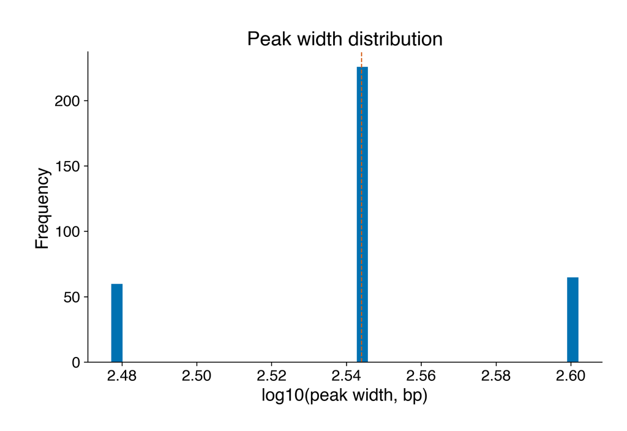

tex qc peak widthDownload: PDF (vector)

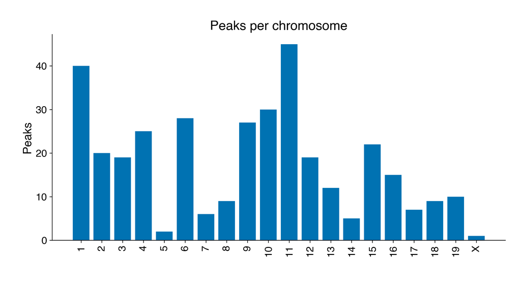

tex qc chromosomesDownload: PDF (vector)

**Table: chromosomes - tex_qc_chromosomes.tsv**

| Chr | N | Pct |
| --- | --- | --- |
| chr11 | 45 | 12.82 |
| chr1 | 40 | 11.4 |
| chr10 | 30 | 8.55 |
| chr6 | 28 | 7.98 |
| chr9 | 27 | 7.69 |
| chr4 | 25 | 7.12 |
| chr15 | 22 | 6.27 |
| chr2 | 20 | 5.7 |
| chr3 | 19 | 5.41 |
| chr12 | 19 | 5.41 |

Showing 10 of 20 rows.

### Annotation

E2

### Peak annotation - GENCODE vM25 basic

ok

Why: Default annotation (-2000/+500 bp promoter window).

| reference | genome: mm10, source: GENCODE vM25 basic, genes: 55401, transcripts: 81540, gene_types: protein_coding, genes_used: 21833, cached: True |
| --- | --- |
| n peaks | 351 |
| region class counts | promoter: 78, distal: 267, distal_far: 6 |
| feature pct | Promoter (<=1kb): 20.2, Promoter (1-2kb): 1.99, 3' UTR: 1.71, Other Exon: 4.27, 1st Intron: 7.41, Other Intron: 17.1, Downstream (<=300bp): 0.28, Distal Intergenic: 47 |
| region distribution pct | Promoters: 22.2, immediateDownstream: 0.28, fiveUTRs: 0, threeUTRs: 1.71, Exons: 4.27, Introns: 24.5, Intergenic.Region: 47 |
| median abs distance to tss | 12,462 |
| gene set sizes | promoter: 77, distal: 160, all: 183 |
| example promoter genes | Stat4, Ikzf2, Pdcd1, Il10, Rgs16, Sell, Cd244a, Myb, Taar9, Prf1, Dusp6, Ifng, Havcr2, Tcf7, Polr2a, Ccl5, Ccl3, Ccl4, Tbx21, Ccr7, Stat3, Socs3, Id2, Fos, Batf, Cipc, Irf4, Gzmk, Gzmb, Ptger4, Il7r, … |
| promoter window | upstream: 2000, downstream: 500 |
| timing sec | reference: 0.03, annotation: 0.03, tables_and_figures: 1.16 |

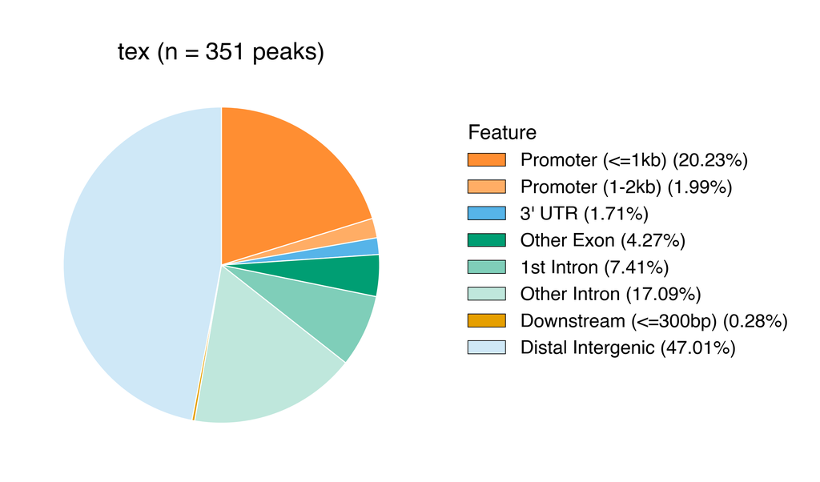

tex feature pieDownload: PDF (vector)

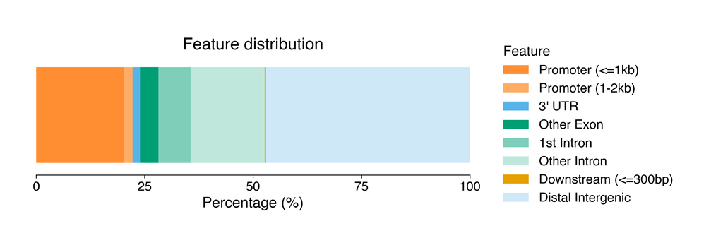

tex feature barDownload: PDF (vector)

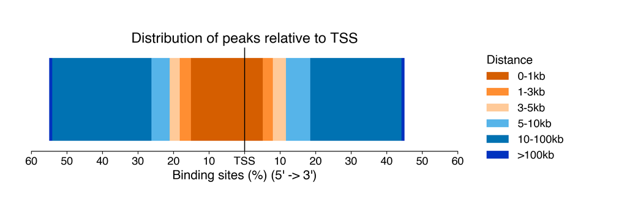

tex tss distance binsDownload: PDF (vector)

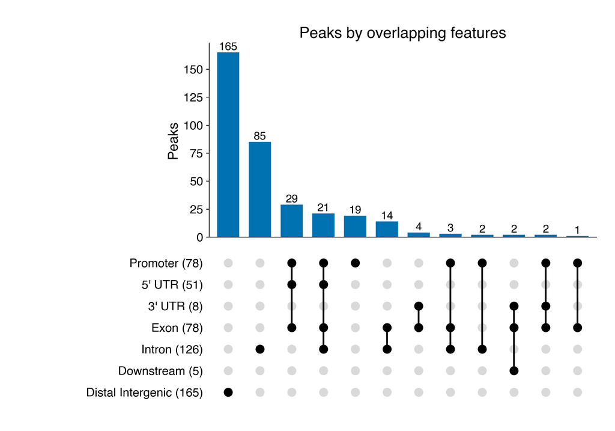

tex feature upsetDownload: PDF (vector)

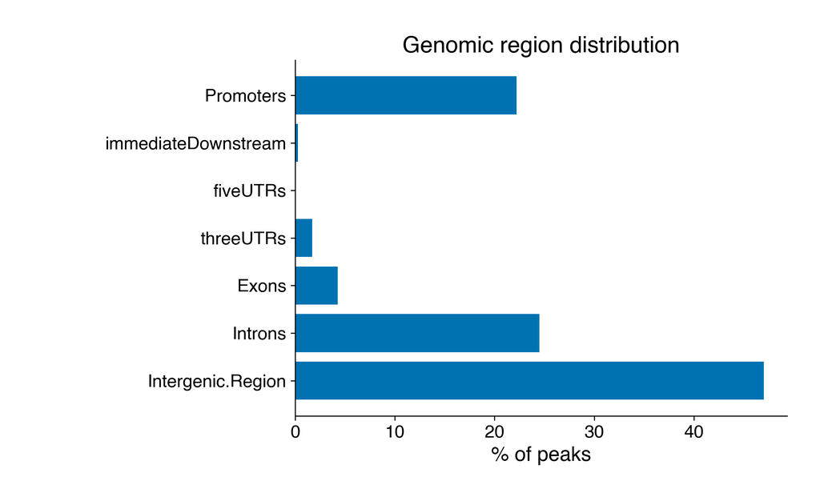

tex region distributionDownload: PDF (vector)

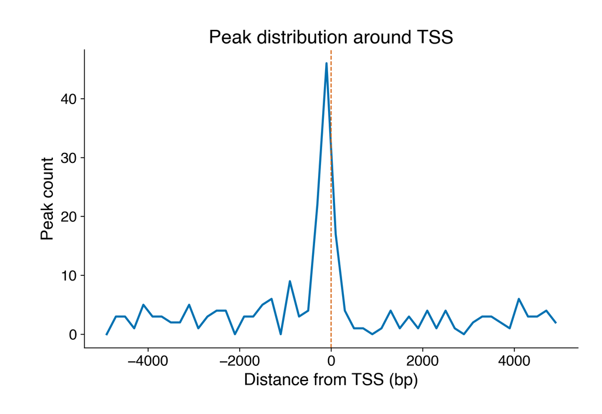

tex tss profileDownload: PDF (vector)

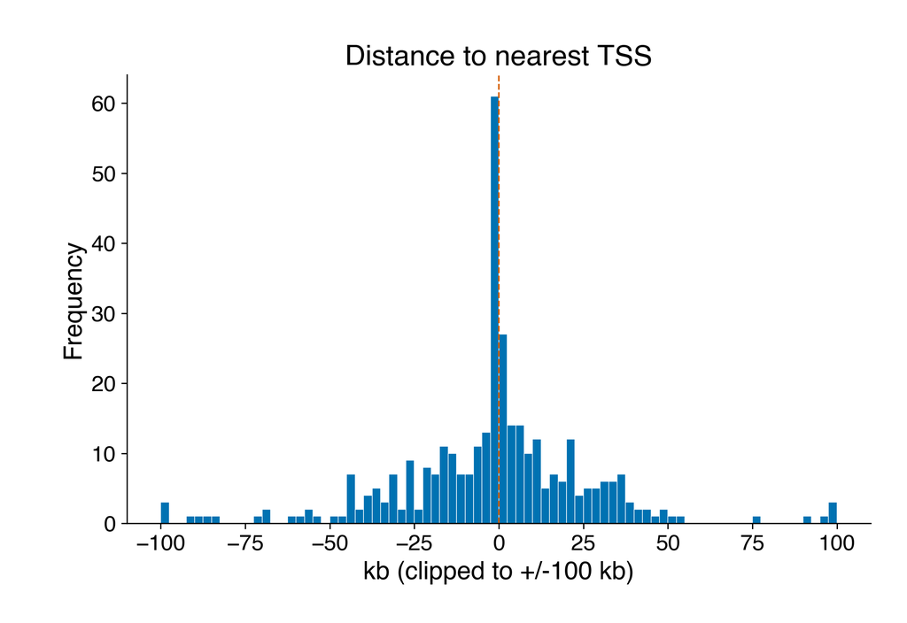

tex tss distanceDownload: PDF (vector)

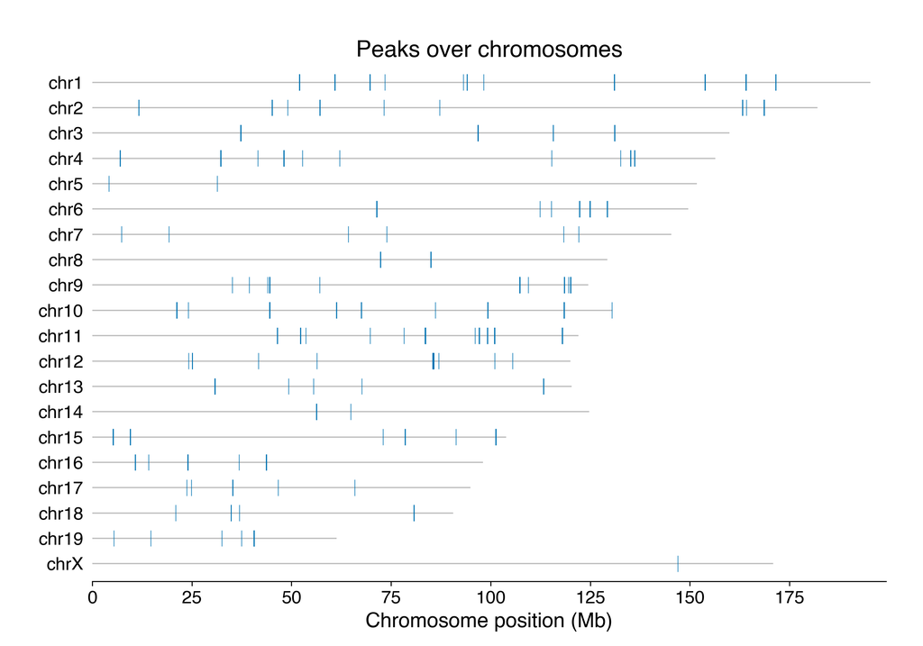

tex chromosome coverageDownload: PDF (vector)

**Table: peak_genes - tex_peak_genes.tsv**

| PeakID | Chr | Start | End | feature | feature_overlaps | nearest_symbol | nearest_gene_id | nearest_gene_type | nearest_transcript | distance_to_tss | promoter_symbols | promoter_gene_ids | region_class |
| --- | --- | --- | --- | --- | --- | --- | --- | --- | --- | --- | --- | --- | --- |
| tex_peak_0001 | chr1 | 51937897 | 51938247 | Distal Intergenic | Distal Intergenic | Myo1b | ENSMUSG00000018417.14 | protein_coding | ENSMUST00000046390.13 | -22001 | NA | NA | distal |
| tex_peak_0002 | chr1 | 51946851 | 51947201 | Distal Intergenic | Distal Intergenic | Myo1b | ENSMUSG00000018417.14 | protein_coding | ENSMUST00000046390.13 | -30955 | NA | NA | distal |
| tex_peak_0003 | chr1 | 51970712 | 51971062 | Distal Intergenic | Distal Intergenic | Stat4 | ENSMUSG00000062939.11 | protein_coding | ENSMUST00000168302.7 | -16261 | NA | NA | distal |
| tex_peak_0004 | chr1 | 51986720 | 51987120 | Promoter (<=1kb) | Promoter | Stat4 | ENSMUSG00000062939.11 | protein_coding | ENSMUST00000168302.7 | -228 | Stat4 | ENSMUSG00000062939.11 | promoter |
| tex_peak_0005 | chr1 | 52014147 | 52014497 | Other Intron | Intron | Stat4 | ENSMUSG00000062939.11 | protein_coding | ENSMUST00000027277.6 | 6079 | NA | NA | distal |
| tex_peak_0006 | chr1 | 60836977 | 60837327 | Distal Intergenic | Distal Intergenic | Ctla4 | ENSMUSG00000026011.13 | protein_coding | ENSMUST00000027164.8 | -71873 | NA | NA | distal |
| tex_peak_0007 | chr1 | 60851151 | 60851501 | Distal Intergenic | Distal Intergenic | Ctla4 | ENSMUSG00000026011.13 | protein_coding | ENSMUST00000027164.8 | -57699 | NA | NA | distal |
| tex_peak_0008 | chr1 | 60864420 | 60864770 | Distal Intergenic | Distal Intergenic | Ctla4 | ENSMUSG00000026011.13 | protein_coding | ENSMUST00000027164.8 | -44430 | NA | NA | distal |
| tex_peak_0009 | chr1 | 60886890 | 60887290 | Distal Intergenic | Distal Intergenic | Ctla4 | ENSMUSG00000026011.13 | protein_coding | ENSMUST00000027164.8 | -21935 | NA | NA | distal |
| tex_peak_0010 | chr1 | 60937771 | 60938121 | Distal Intergenic | Distal Intergenic | Ctla4 | ENSMUSG00000026011.13 | protein_coding | ENSMUST00000097720.3 | 28775 | NA | NA | distal |

Showing 10 of 351 rows.

**Table: feature_distribution - tex_feature_distribution.tsv**

| Annotation | Freq | Pct |
| --- | --- | --- |
| Promoter (<=1kb) | 71 | 20.23 |
| Promoter (1-2kb) | 7 | 1.99 |
| 3' UTR | 6 | 1.71 |
| Other Exon | 15 | 4.27 |
| 1st Intron | 26 | 7.41 |
| Other Intron | 60 | 17.09 |
| Downstream (<=300bp) | 1 | 0.28 |
| Distal Intergenic | 165 | 47.01 |

**Table: region_distribution - tex_region_distribution.tsv**

| Region | Pct |
| --- | --- |
| Promoters | 22.22 |
| immediateDownstream | 0.28 |
| fiveUTRs | 0.0 |
| threeUTRs | 1.71 |
| Exons | 4.27 |
| Introns | 24.5 |
| Intergenic.Region | 47.01 |

**Table: tss_distance_bins - tex_tss_distance_bins.tsv**

| Bin | Side | N | Pct |
| --- | --- | --- | --- |
| 0-1kb | upstream | 53 | 15.1 |
| 1-3kb | upstream | 11 | 3.13 |
| 3-5kb | upstream | 10 | 2.85 |
| 5-10kb | upstream | 18 | 5.13 |
| 10-100kb | upstream | 98 | 27.92 |
| >100kb | upstream | 3 | 0.85 |
| 0-1kb | downstream | 18 | 5.13 |
| 1-3kb | downstream | 10 | 2.85 |
| 3-5kb | downstream | 13 | 3.7 |
| 5-10kb | downstream | 24 | 6.84 |

Showing 10 of 12 rows.

### Pathways

E4

### Pathway enrichment (go_bp, kegg, hallmark, custom)

ok

Why: Standard GO/KEGG/Hallmark ORA on peak-linked genes.

#### Explore the pathways

Interactive view needs JavaScript.

| methods | go_bp, kegg, hallmark, custom |
| --- | --- |
| gene set sources | go_bp: MSigDB m5.go.bp.v2024.1.Mm.symbols.gmt, kegg: Enrichr KEGG_2019_Mouse, hallmark: MSigDB mh.all.v2024.1.Mm.symbols.gmt, custom: GMT example_tex_signatures.gmt |
| groups | promoter: 77, distal: 160, all: 183 |
| universe size | 21833 |

#### n significant

| method | group | N |
| --- | --- | --- |
| go_bp | promoter | 502 |
| go_bp | distal | 197 |
| go_bp | all | 273 |
| kegg | promoter | 40 |
| kegg | distal | 18 |
| kegg | all | 27 |
| hallmark | promoter | 6 |
| hallmark | distal | 6 |
| hallmark | all | 6 |
| custom | promoter | 3 |
| custom | distal | 3 |
| custom | all | 3 |

#### top terms

| method | group | term | padj | count | genes |
| --- | --- | --- | --- | --- | --- |
| go_bp | promoter | GOBP_ALPHA_BETA_T_CELL_ACTIVATION | 1.21e-18 | 20 | Batf;Bcl6;Ccr7;Cd160;Cd244a;Eomes;Ifng;Il21;Il2ra;Irf4;Lef1;Myb |
| go_bp | promoter | GOBP_CD4_POSITIVE_ALPHA_BETA_T_CELL_ACTIVATION | 2.36e-17 | 17 | Batf;Bcl6;Ccr7;Cd160;Ifng;Il21;Il2ra;Irf4;Lef1;Myb;Ptger4;Runx3 |
| go_bp | promoter | GOBP_ALPHA_BETA_T_CELL_DIFFERENTIATION | 3.41e-17 | 17 | Batf;Bcl6;Ccr7;Eomes;Ifng;Il21;Irf4;Lef1;Myb;Ptger4;Runx3;Socs1 |
| go_bp | promoter | GOBP_T_CELL_DIFFERENTIATION | 3.43e-17 | 22 | Batf;Bcl6;Ccr7;Cd8a;Egr1;Eomes;Ifng;Il21;Il2ra;Il7r;Irf4;Lag3 |
| go_bp | promoter | GOBP_ADAPTIVE_IMMUNE_RESPONSE | 1.92e-16 | 24 | Bach2;Batf;Bcl6;Ccr7;Cd160;Cd244a;Cd8a;Cd8b1;Cx3cr1;Eomes;Gzmb;Havcr2 |
| go_bp | promoter | GOBP_CD4_POSITIVE_ALPHA_BETA_T_CELL_DIFFERENTIATION | 1.92e-16 | 15 | Batf;Bcl6;Ccr7;Ifng;Il21;Irf4;Lef1;Myb;Ptger4;Runx3;Socs1;Stat3 |
| go_bp | promoter | GOBP_T_CELL_DIFFERENTIATION_INVOLVED_IN_IMMUNE_RESPONSE | 2.62e-14 | 13 | Batf;Bcl6;Ccr7;Eomes;Ifng;Il21;Irf4;Lef1;Myb;Ptger4;Stat3;Stat4 |
| go_bp | promoter | GOBP_LYMPHOCYTE_ACTIVATION_INVOLVED_IN_IMMUNE_RESPONSE | 4.53e-14 | 17 | Batf;Bcl6;Ccr7;Cd160;Cd244a;Eomes;Havcr2;Ifng;Il10;Il21;Irf4;Lef1 |
| go_bp | distal | GOBP_T_CELL_DIFFERENTIATION | 4.84e-12 | 24 | Bcl6;Ccr7;Cd8a;Ctla4;Egr1;Eomes;Ifng;Il21;Il2ra;Il7r;Irf4;Lef1 |
| go_bp | distal | GOBP_ALPHA_BETA_T_CELL_DIFFERENTIATION | 6.66e-12 | 17 | Bcl6;Ccr7;Eomes;Ifng;Il21;Irf4;Lef1;Myb;Prdm1;Ptger4;Runx3;Socs1 |
| go_bp | distal | GOBP_ALPHA_BETA_T_CELL_ACTIVATION | 6.89e-12 | 19 | Bcl6;Ccr7;Cd160;Eomes;Ifng;Il21;Il2ra;Irf4;Lef1;Myb;Prdm1;Ptger4 |
| go_bp | distal | GOBP_CD4_POSITIVE_ALPHA_BETA_T_CELL_ACTIVATION | 2.87e-11 | 16 | Bcl6;Ccr7;Cd160;Ifng;Il21;Il2ra;Irf4;Lef1;Myb;Ptger4;Runx3;Socs1 |

Showing 12 of 75 rows.

#### go bp

| module | lead_term | n_terms | best_padj | other_terms |
| --- | --- | --- | --- | --- |
| 1 | GOBP_ALPHA_BETA_T_CELL_ACTIVATION | 4 | 1.21e-18 | GOBP_CD4_POSITIVE_ALPHA_BETA_T_CELL_ACTIVATION; GOBP_ALPHA_BETA_T_CELL_DIFFERENTIATION; GOBP_T_CELL_DIFFERENTIATION |
| 2 | GOBP_ADAPTIVE_IMMUNE_RESPONSE | 4 | 1.92e-16 | GOBP_ADAPTIVE_IMMUNE_RESPONSE_BASED_ON_SOMATIC_RECOMBINATION_OF_IMMUNE_RECEPTORS_BUILT_FROM_IMMUNOGLOBULIN_SUPERFAMILY_DOMAINS; GOBP_LEUKOCYTE_MEDIATED_IMMUNITY; GOBP_LYMPHOCYTE_MEDIATED_IMMUNITY |
| 3 | GOBP_CD4_POSITIVE_ALPHA_BETA_T_CELL_DIFFERENTIATION | 6 | 1.92e-16 | GOBP_T_CELL_DIFFERENTIATION_INVOLVED_IN_IMMUNE_RESPONSE; GOBP_LYMPHOCYTE_ACTIVATION_INVOLVED_IN_IMMUNE_RESPONSE; GOBP_CELL_ACTIVATION_INVOLVED_IN_IMMUNE_RESPONSE |
| 4 | GOBP_POSITIVE_REGULATION_OF_CELL_ACTIVATION | 7 | 6.66e-14 | GOBP_LEUKOCYTE_CELL_CELL_ADHESION; GOBP_POSITIVE_REGULATION_OF_LYMPHOCYTE_ACTIVATION; GOBP_REGULATION_OF_T_CELL_ACTIVATION |
| 5 | GOBP_REGULATION_OF_HEMOPOIESIS | 9 | 6.66e-14 | GOBP_POSITIVE_REGULATION_OF_HEMOPOIESIS; GOBP_REGULATION_OF_LEUKOCYTE_DIFFERENTIATION; GOBP_IMMUNE_SYSTEM_DEVELOPMENT |

#### kegg

| module | lead_term | n_terms | best_padj | other_terms |
| --- | --- | --- | --- | --- |
| 1 | Th17 cell differentiation | 7 | 3.56e-07 | Inflammatory bowel disease (IBD); Th1 and Th2 cell differentiation; JAK-STAT signaling pathway |
| 2 | T cell receptor signaling pathway | 5 | 1.22e-06 | Osteoclast differentiation; Hematopoietic cell lineage; Cell adhesion molecules (CAMs) |
| 3 | Cytokine-cytokine receptor interaction | 8 | 2.43e-06 | Rheumatoid arthritis; Chagas disease (American trypanosomiasis); Human cytomegalovirus infection |
| 4 | Natural killer cell mediated cytotoxicity | 4 | 3.08e-04 | Allograft rejection; Graft-versus-host disease; Type I diabetes mellitus |
| 5 | FoxO signaling pathway | 1 | 0.00398 |  |
| 6 | Transcriptional misregulation in cancer | 1 | 0.00557 |  |
| 7 | Toxoplasmosis | 3 | 0.00764 | Leishmaniasis; African trypanosomiasis |
| 8 | Acute myeloid leukemia | 1 | 0.00871 |  |

#### hallmark

| module | lead_term | n_terms | best_padj | other_terms |
| --- | --- | --- | --- | --- |
| 1 | HALLMARK_TNFA_SIGNALING_VIA_NFKB | 1 | 1.98e-08 |  |
| 2 | HALLMARK_ALLOGRAFT_REJECTION | 2 | 4.88e-07 | HALLMARK_IL2_STAT5_SIGNALING |
| 3 | HALLMARK_INFLAMMATORY_RESPONSE | 1 | 0.00103 |  |
| 4 | HALLMARK_INTERFERON_GAMMA_RESPONSE | 2 | 0.00352 | HALLMARK_IL6_JAK_STAT3_SIGNALING |

#### custom

| module | lead_term | n_terms | best_padj | other_terms |
| --- | --- | --- | --- | --- |
| 1 | TEX_TERMINAL | 1 | 5.33e-24 |  |
| 2 | TEX_EFFECTOR_LIKE | 1 | 2.47e-20 |  |
| 3 | TEX_PROGENITOR | 1 | 1.48e-19 |  |

#### go bp

| gene | n_pathways |
| --- | --- |
| Bcl6 | 5 |
| Ccr7 | 5 |
| Ifng | 5 |
| Lef1 | 5 |
| Tbx21 | 5 |
| Il21 | 4 |
| Myb | 4 |
| Runx3 | 4 |
| Socs1 | 4 |
| Stat3 | 4 |
| Tox | 4 |
| Batf | 3 |

Showing 12 of 15 rows.

#### kegg

| gene | n_pathways |
| --- | --- |
| Ifng | 4 |
| Il10 | 3 |
| Nfatc1 | 3 |
| Nfatc2 | 3 |
| Tnf | 3 |
| Fos | 2 |
| Il21 | 2 |
| Il2ra | 2 |
| Il2rb | 2 |
| Il7r | 2 |
| Stat3 | 2 |

#### hallmark

| gene | n_pathways |
| --- | --- |
| Ccl5 | 4 |
| Il2rb | 4 |
| Cd69 | 3 |
| Il10 | 3 |
| Il15ra | 3 |
| Irf4 | 3 |
| Socs1 | 3 |
| Il2ra | 2 |
| Il7r | 2 |
| Ltb | 2 |
| Ptger4 | 2 |
| Rgs16 | 2 |

Showing 12 of 15 rows.

#### custom

| gene | n_pathways |
| --- | --- |
| Cx3cr1 | 2 |
| Gzmb | 2 |

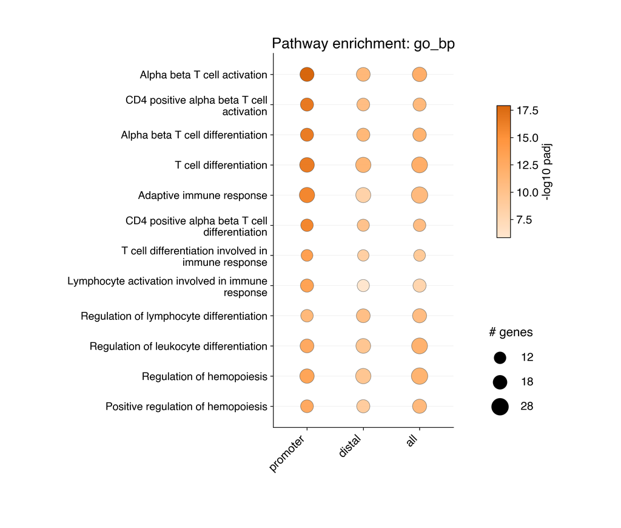

tex enrich1 enrichment go bp dotplotDownload: PDF (vector)

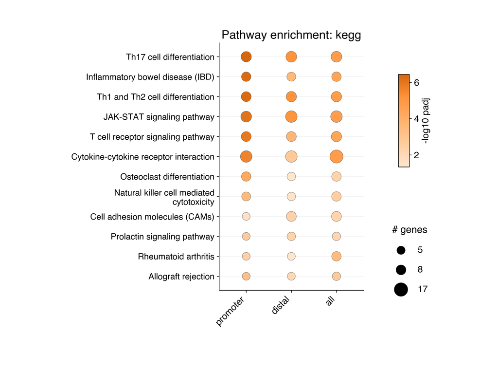

tex enrich1 enrichment kegg dotplotDownload: PDF (vector)

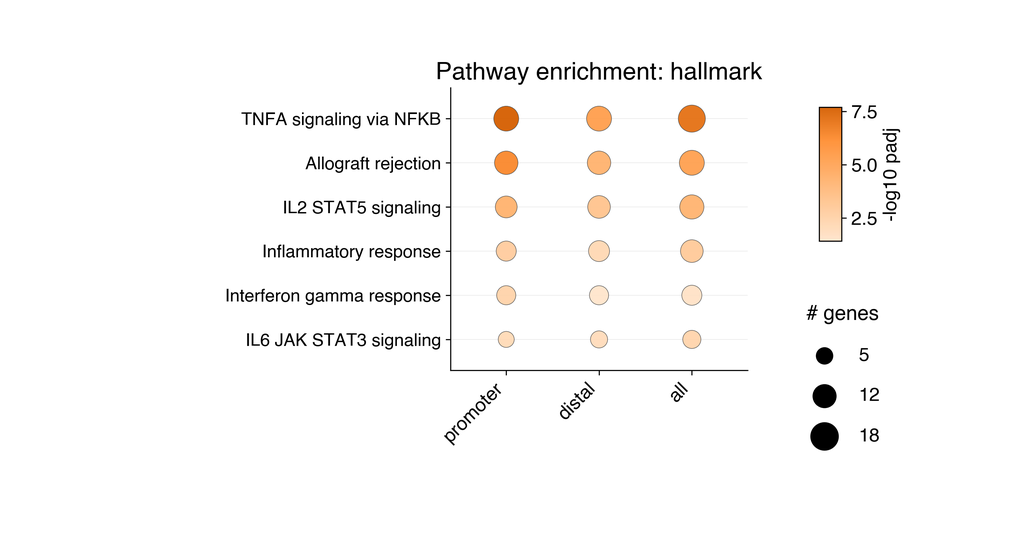

tex enrich1 enrichment hallmark dotplotDownload: PDF (vector)

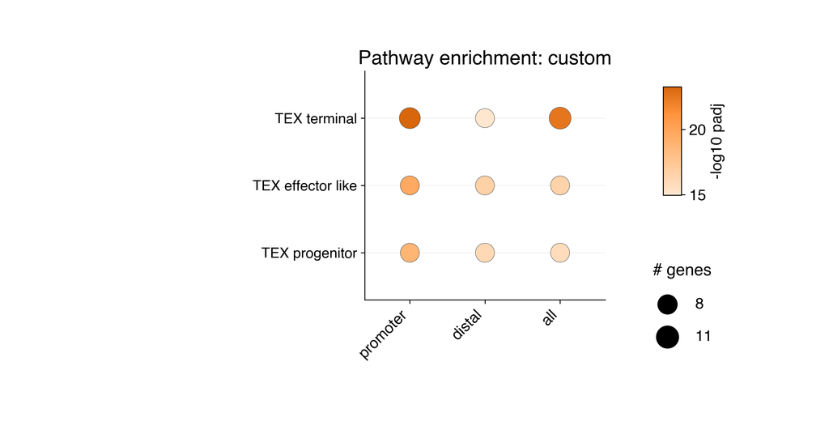

tex enrich1 enrichment custom dotplotDownload: PDF (vector)

[figure not shown]

tex enrich1 network go bpDownload: PDF (vector)

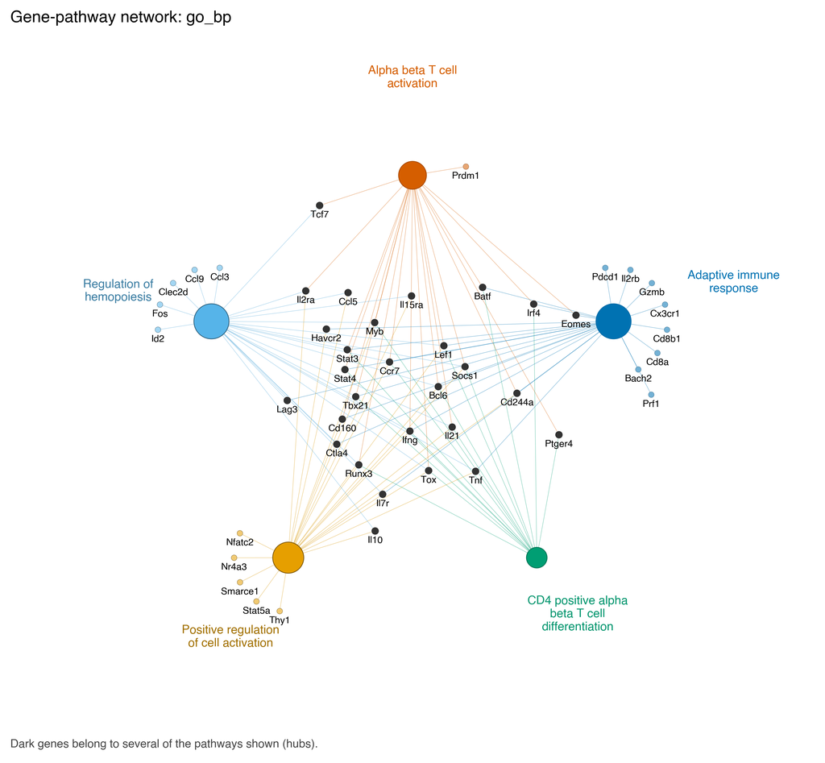

tex enrich1 cnet go bpDownload: PDF (vector)

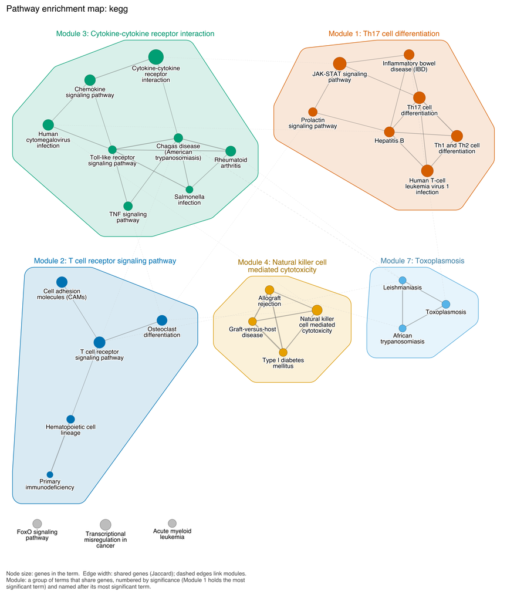

tex enrich1 network keggDownload: PDF (vector)

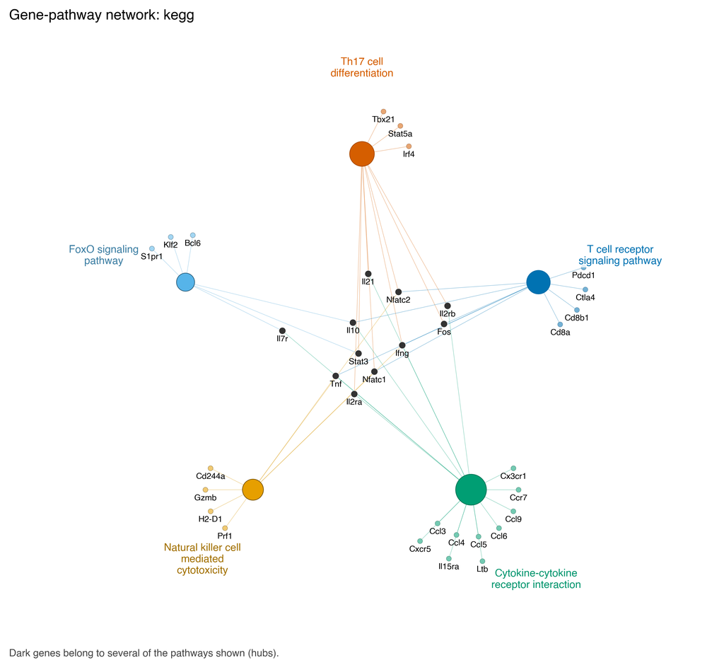

tex enrich1 cnet keggDownload: PDF (vector)

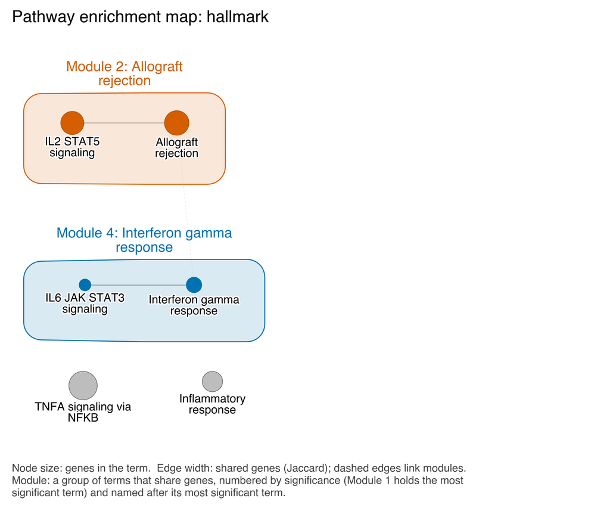

tex enrich1 network hallmarkDownload: PDF (vector)

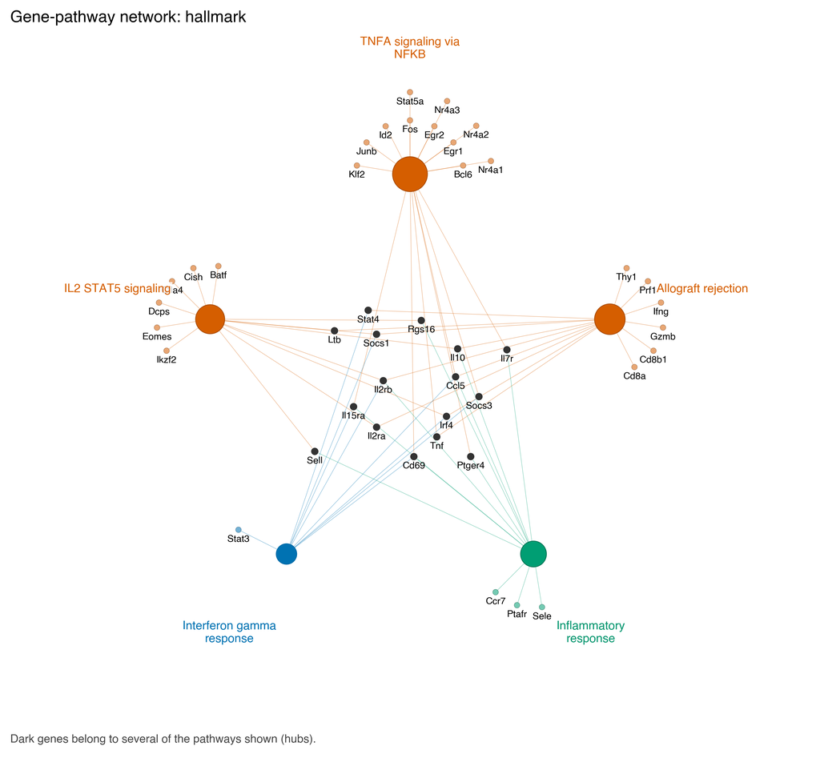

tex enrich1 cnet hallmarkDownload: PDF (vector)

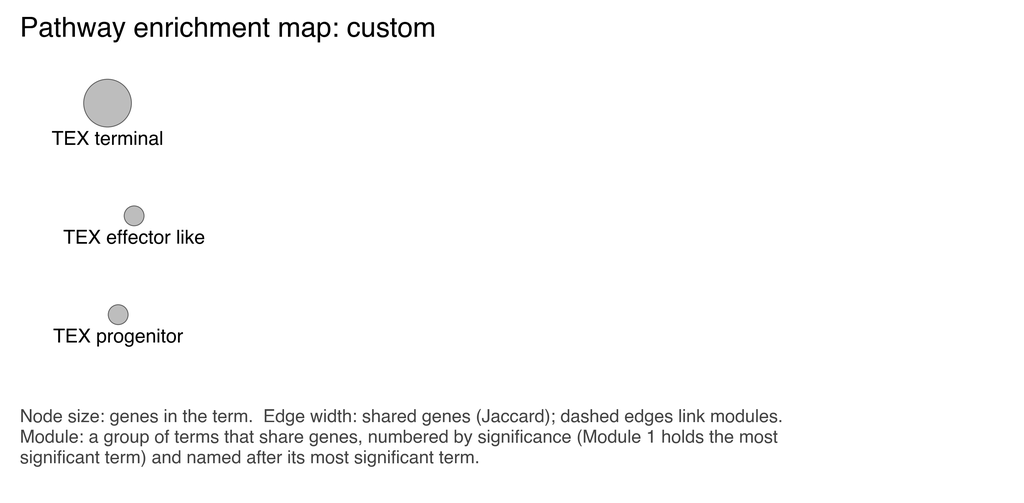

tex enrich1 network customDownload: PDF (vector)

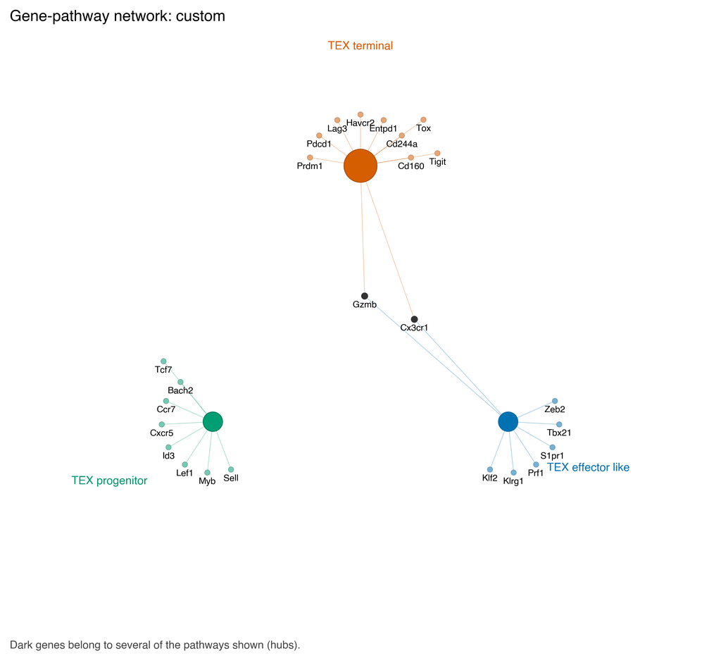

tex enrich1 cnet customDownload: PDF (vector)

**Table: enrichment - tex_enrich1_enrichment.tsv**

| method | group | term_id | term | gene_ratio | bg_ratio | pvalue | padj | count | genes |
| --- | --- | --- | --- | --- | --- | --- | --- | --- | --- |
| go_bp | promoter | GOBP_ACIDIC_AMINO_ACID_TRANSPORT | GOBP_ACIDIC_AMINO_ACID_TRANSPORT | 1/69 | 79/14857 | 0.3083833373526968 | 0.37622615697904066 | 1 | Tnf |
| go_bp | promoter | GOBP_ACID_SECRETION | GOBP_ACID_SECRETION | 1/69 | 58/14857 | 0.23701423955424358 | 0.31821508743488436 | 1 | Tnf |
| go_bp | promoter | GOBP_ACTIN_FILAMENT_BASED_MOVEMENT | GOBP_ACTIN_FILAMENT_BASED_MOVEMENT | 1/69 | 126/14857 | 0.445134224162426 | 0.49311887676709115 | 1 | Zeb2 |
| go_bp | promoter | GOBP_ACTIN_FILAMENT_BUNDLE_ORGANIZATION | GOBP_ACTIN_FILAMENT_BUNDLE_ORGANIZATION | 3/69 | 183/14857 | 0.053345878433741334 | 0.13936765971581166 | 3 | Ptger4;S1pr1;Zeb2 |
| go_bp | promoter | GOBP_ACTIN_FILAMENT_ORGANIZATION | GOBP_ACTIN_FILAMENT_ORGANIZATION | 4/69 | 464/14857 | 0.16883429987040313 | 0.26158332592282635 | 4 | Ptger4;S1pr1;Xirp1;Zeb2 |
| go_bp | promoter | GOBP_ACTIN_MEDIATED_CELL_CONTRACTION | GOBP_ACTIN_MEDIATED_CELL_CONTRACTION | 1/69 | 100/14857 | 0.3731643743078578 | 0.43352589967695804 | 1 | Zeb2 |
| go_bp | promoter | GOBP_ACTION_POTENTIAL | GOBP_ACTION_POTENTIAL | 2/69 | 176/14857 | 0.19690871330950446 | 0.28603581512328013 | 2 | Ifng;Tnf |
| go_bp | promoter | GOBP_ACTIVATED_T_CELL_PROLIFERATION | GOBP_ACTIVATED_T_CELL_PROLIFERATION | 1/69 | 52/14857 | 0.2153223425249639 | 0.3023275913940627 | 1 | Il2ra |
| go_bp | promoter | GOBP_ACTIVATION_INDUCED_CELL_DEATH_OF_T_CELLS | GOBP_ACTIVATION_INDUCED_CELL_DEATH_OF_T_CELLS | 1/69 | 14/14857 | 0.06311984395069675 | 0.15018169767579573 | 1 | Il2ra |
| go_bp | promoter | GOBP_ACTIVATION_OF_CYSTEINE_TYPE_ENDOPEPTIDASE_ACTIVITY_INVOLVED_IN_APOPTOTIC_PROCESS | GOBP_ACTIVATION_OF_CYSTEINE_TYPE_ENDOPEPTIDASE_ACTIVITY_INVOLVED_IN_APOPTOTIC_PROCESS | 1/69 | 85/14857 | 0.32753715453232723 | 0.39383518728102557 | 1 | Tnf |

Showing 10 of 7284 rows.

**Table: network_nodes_go_bp - tex_enrich1_network_go_bp_nodes.tsv**

| term | module | module_label | padj | count | groups | genes | x | y |
| --- | --- | --- | --- | --- | --- | --- | --- | --- |
| GOBP_ALPHA_BETA_T_CELL_ACTIVATION | 1 | GOBP_ALPHA_BETA_T_CELL_ACTIVATION | 1.2118187684317313e-18 | 21 | all;distal;promoter | Batf;Bcl6;Ccr7;Cd160;Cd244a;Eomes;Ifng;Il21;Il2ra;Irf4;Lef1;Myb;Ptger4;Runx3;Socs1;Stat3;Stat4;Tbx21;Tcf7;Tox;Prdm1 | 10.509 | -10.655 |
| GOBP_CD4_POSITIVE_ALPHA_BETA_T_CELL_ACTIVATION | 1 | GOBP_ALPHA_BETA_T_CELL_ACTIVATION | 2.3630099881877326e-17 | 17 | all;distal;promoter | Batf;Bcl6;Ccr7;Cd160;Ifng;Il21;Il2ra;Irf4;Lef1;Myb;Ptger4;Runx3;Socs1;Stat3;Stat4;Tbx21;Tox | 9.598 | -9.361 |
| GOBP_ALPHA_BETA_T_CELL_DIFFERENTIATION | 1 | GOBP_ALPHA_BETA_T_CELL_ACTIVATION | 3.4090686383379205e-17 | 18 | all;distal;promoter | Batf;Bcl6;Ccr7;Eomes;Ifng;Il21;Irf4;Lef1;Myb;Ptger4;Runx3;Socs1;Stat3;Stat4;Tbx21;Tcf7;Tox;Prdm1 | 8.401 | -10.654 |
| GOBP_T_CELL_DIFFERENTIATION | 1 | GOBP_ALPHA_BETA_T_CELL_ACTIVATION | 3.4250309177236985e-17 | 26 | all;distal;promoter | Batf;Bcl6;Ccr7;Cd8a;Egr1;Eomes;Ifng;Il21;Il2ra;Il7r;Irf4;Lag3;Lef1;Myb;Ptger4;Runx3;Socs1;Stat3;Stat4;Tbx21;Tcf7;Tox;Ctla4;Prdm1;Smarce1;Stat5a | 9.317 | -11.792 |
| GOBP_ADAPTIVE_IMMUNE_RESPONSE | 2 | GOBP_ADAPTIVE_IMMUNE_RESPONSE | 1.9210943632398757e-16 | 28 | all;distal;promoter | Bach2;Batf;Bcl6;Ccr7;Cd160;Cd244a;Cd8a;Cd8b1;Cx3cr1;Eomes;Gzmb;Havcr2;Ifng;Il2rb;Il7r;Irf4;Lag3;Lef1;Pdcd1;Prf1;Stat3;Stat4;Tbx21;Tnf;Ctla4;H2-D1;Prdm1;Rnf125 | 5.458 | -16.665 |
| GOBP_ADAPTIVE_IMMUNE_RESPONSE_BASED_ON_SOMATIC_RECOMBINATION_OF_IMMUNE_RECEPTORS_BUILT_FROM_IMMUNOGLOBULIN_SUPERFAMILY_DOMAINS | 2 | GOBP_ADAPTIVE_IMMUNE_RESPONSE | 1.9645838399389014e-11 | 18 | all;distal;promoter | Bach2;Batf;Bcl6;Ccr7;Cd8a;Gzmb;Havcr2;Ifng;Il2rb;Il7r;Irf4;Lef1;Prf1;Stat3;Stat4;Tbx21;Tnf;H2-D1 | 3.457 | -15.495 |
| GOBP_LEUKOCYTE_MEDIATED_IMMUNITY | 2 | GOBP_ADAPTIVE_IMMUNE_RESPONSE | 1.0280621650023845e-08 | 20 | all;distal;promoter | Batf;Bcl6;Cd160;Cd8a;Cx3cr1;Gzmb;Havcr2;Ifng;Il21;Il2rb;Il7r;Lag3;Nr4a3;Prf1;Tbx21;Tnf;Clec2d;H2-D1;Ptafr;Stat5a | 1.302 | -16.998 |
| GOBP_LYMPHOCYTE_MEDIATED_IMMUNITY | 2 | GOBP_ADAPTIVE_IMMUNE_RESPONSE | 1.9163312887652056e-08 | 17 | all;distal;promoter | Batf;Bcl6;Cd160;Cd8a;Gzmb;Havcr2;Ifng;Il21;Il2rb;Il7r;Lag3;Prf1;Tbx21;Tnf;Clec2d;H2-D1;Stat5a | 3.505 | -18.16 |
| GOBP_CD4_POSITIVE_ALPHA_BETA_T_CELL_DIFFERENTIATION | 3 | GOBP_CD4_POSITIVE_ALPHA_BETA_T_CELL_DIFFERENTIATION | 1.9210943632398757e-16 | 15 | all;distal;promoter | Batf;Bcl6;Ccr7;Ifng;Il21;Irf4;Lef1;Myb;Ptger4;Runx3;Socs1;Stat3;Stat4;Tbx21;Tox | 5.35 | -9.341 |
| GOBP_T_CELL_DIFFERENTIATION_INVOLVED_IN_IMMUNE_RESPONSE | 3 | GOBP_CD4_POSITIVE_ALPHA_BETA_T_CELL_DIFFERENTIATION | 2.616922960706193e-14 | 13 | all;distal;promoter | Batf;Bcl6;Ccr7;Eomes;Ifng;Il21;Irf4;Lef1;Myb;Ptger4;Stat3;Stat4;Tbx21 | 3.135 | -9.403 |

Showing 10 of 30 rows.

**Table: network_edges_go_bp - tex_enrich1_network_go_bp_edges.tsv**

| from | to | jaccard |
| --- | --- | --- |
| GOBP_ALPHA_BETA_T_CELL_ACTIVATION | GOBP_CD4_POSITIVE_ALPHA_BETA_T_CELL_ACTIVATION | 0.81 |
| GOBP_ALPHA_BETA_T_CELL_ACTIVATION | GOBP_ALPHA_BETA_T_CELL_DIFFERENTIATION | 0.857 |
| GOBP_ALPHA_BETA_T_CELL_ACTIVATION | GOBP_T_CELL_DIFFERENTIATION | 0.679 |
| GOBP_ALPHA_BETA_T_CELL_ACTIVATION | GOBP_CD4_POSITIVE_ALPHA_BETA_T_CELL_DIFFERENTIATION | 0.714 |
| GOBP_CD4_POSITIVE_ALPHA_BETA_T_CELL_ACTIVATION | GOBP_ALPHA_BETA_T_CELL_DIFFERENTIATION | 0.75 |
| GOBP_CD4_POSITIVE_ALPHA_BETA_T_CELL_ACTIVATION | GOBP_T_CELL_DIFFERENTIATION | 0.593 |
| GOBP_CD4_POSITIVE_ALPHA_BETA_T_CELL_ACTIVATION | GOBP_CD4_POSITIVE_ALPHA_BETA_T_CELL_DIFFERENTIATION | 0.882 |
| GOBP_ALPHA_BETA_T_CELL_DIFFERENTIATION | GOBP_T_CELL_DIFFERENTIATION | 0.692 |
| GOBP_ALPHA_BETA_T_CELL_DIFFERENTIATION | GOBP_CD4_POSITIVE_ALPHA_BETA_T_CELL_DIFFERENTIATION | 0.833 |
| GOBP_T_CELL_DIFFERENTIATION | GOBP_IMMUNE_SYSTEM_DEVELOPMENT | 0.387 |

Showing 10 of 56 rows.

**Table: network_nodes_kegg - tex_enrich1_network_kegg_nodes.tsv**

| term | module | module_label | padj | count | groups | genes | x | y |
| --- | --- | --- | --- | --- | --- | --- | --- | --- |
| Th17 cell differentiation | 1 | Th17 cell differentiation | 3.562076232392064e-07 | 11 | all;distal;promoter | Fos;Ifng;Il21;Il2ra;Il2rb;Irf4;Nfatc1;Nfatc2;Stat3;Tbx21;Stat5a | 13.001 | -2.323 |
| Inflammatory bowel disease (IBD) | 1 | Th17 cell differentiation | 4.880648345852611e-07 | 8 | all;distal;promoter | Ifng;Il10;Il21;Nfatc1;Stat3;Stat4;Tbx21;Tnf | 12.671 | -0.948 |
| Th1 and Th2 cell differentiation | 1 | Th17 cell differentiation | 4.880648345852611e-07 | 10 | all;distal;promoter | Fos;Ifng;Il2ra;Il2rb;Nfatc1;Nfatc2;Runx3;Stat4;Tbx21;Stat5a | 14.203 | -3.547 |
| JAK-STAT signaling pathway | 1 | Th17 cell differentiation | 7.801350455262329e-07 | 13 | all;distal;promoter | Cish;Ifng;Il10;Il21;Il2ra;Il2rb;Il7r;Socs1;Socs3;Stat3;Stat4;Il15ra;Stat5a | 10.456 | -1.237 |
| Prolactin signaling pathway | 1 | Th17 cell differentiation | 0.0022302900810531397 | 6 | all;distal;promoter | Cish;Fos;Socs1;Socs3;Stat3;Stat5a | 9.597 | -2.781 |
| Human T-cell leukemia virus 1 infection | 1 | Th17 cell differentiation | 0.006419832128213276 | 11 | all;distal;promoter | Egr1;Fos;Il2ra;Il2rb;Nfatc1;Nfatc2;Tnf;Egr2;H2-D1;Il15ra;Stat5a | 13.255 | -4.66 |
| Hepatitis B | 1 | Th17 cell differentiation | 0.007719137731385639 | 8 | all;distal;promoter | Fos;Nfatc1;Nfatc2;Stat3;Stat4;Tnf;Egr2;Stat5a | 12.041 | -3.417 |
| T cell receptor signaling pathway | 2 | T cell receptor signaling pathway | 1.2210846480137989e-06 | 10 | all;distal;promoter | Cd8a;Cd8b1;Fos;Ifng;Il10;Nfatc1;Nfatc2;Pdcd1;Tnf;Ctla4 | 2.78 | -10.141 |
| Osteoclast differentiation | 2 | T cell receptor signaling pathway | 5.8541277177705654e-05 | 8 | all;distal;promoter | Fos;Ifng;Junb;Nfatc1;Nfatc2;Socs1;Socs3;Tnf | 4.777 | -9.436 |
| Hematopoietic cell lineage | 2 | T cell receptor signaling pathway | 0.004347738596570683 | 5 | promoter | Cd8a;Cd8b1;Il2ra;Il7r;Tnf | 1.858 | -12.596 |

Showing 10 of 30 rows.

**Table: network_edges_kegg - tex_enrich1_network_kegg_edges.tsv**

| from | to | jaccard |
| --- | --- | --- |
| Th17 cell differentiation | Inflammatory bowel disease (IBD) | 0.357 |
| Th17 cell differentiation | Th1 and Th2 cell differentiation | 0.615 |
| Th17 cell differentiation | JAK-STAT signaling pathway | 0.333 |
| Th17 cell differentiation | Human T-cell leukemia virus 1 infection | 0.375 |
| Th17 cell differentiation | Hepatitis B | 0.357 |
| Inflammatory bowel disease (IBD) | JAK-STAT signaling pathway | 0.312 |
| Inflammatory bowel disease (IBD) | Toxoplasmosis | 0.444 |
| Inflammatory bowel disease (IBD) | Hepatitis B | 0.333 |
| Th1 and Th2 cell differentiation | Human T-cell leukemia virus 1 infection | 0.4 |
| Th1 and Th2 cell differentiation | Hepatitis B | 0.385 |

Showing 10 of 50 rows.

**Table: network_nodes_hallmark - tex_enrich1_network_hallmark_nodes.tsv**

| term | module | module_label | padj | count | groups | genes | x | y |
| --- | --- | --- | --- | --- | --- | --- | --- | --- |
| HALLMARK_TNFA_SIGNALING_VIA_NFKB | 1 | HALLMARK_TNFA_SIGNALING_VIA_NFKB | 1.9763640237748657e-08 | 18 | all;distal;promoter | Bcl6;Ccl5;Cd69;Egr1;Fos;Id2;Il7r;Junb;Klf2;Nr4a1;Nr4a2;Nr4a3;Ptger4;Socs3;Tnf;Egr2;Il15ra;Stat5a | 1.003 | -5.704 |
| HALLMARK_ALLOGRAFT_REJECTION | 2 | HALLMARK_ALLOGRAFT_REJECTION | 4.883030437467805e-07 | 15 | all;distal;promoter | Ccl5;Cd8a;Cd8b1;Gzmb;Ifng;Il10;Il2ra;Il2rb;Irf4;Prf1;Socs1;Stat4;Tnf;Ltb;Thy1 | 2.584 | -1.274 |
| HALLMARK_IL2_STAT5_SIGNALING | 2 | HALLMARK_ALLOGRAFT_REJECTION | 4.9303007032238445e-05 | 14 | all;distal;promoter | Batf;Cish;Eomes;Ikzf2;Il10;Il2ra;Il2rb;Irf4;Rgs16;Sell;Socs1;Ctla4;Dcps;Ltb | 0.821 | -1.274 |
| HALLMARK_INFLAMMATORY_RESPONSE | 3 | HALLMARK_INFLAMMATORY_RESPONSE | 0.0010276548835902607 | 12 | all;distal;promoter | Ccl5;Ccr7;Cd69;Il10;Il2rb;Il7r;Ptger4;Rgs16;Sell;Il15ra;Ptafr;Sele | 3.187 | -5.636 |
| HALLMARK_INTERFERON_GAMMA_RESPONSE | 4 | HALLMARK_INTERFERON_GAMMA_RESPONSE | 0.0035231564849964926 | 9 | all;distal;promoter | Ccl5;Cd69;Il2rb;Irf4;Socs1;Socs3;Stat3;Stat4;Il15ra | 2.876 | -4.006 |
| HALLMARK_IL6_JAK_STAT3_SIGNALING | 4 | HALLMARK_INTERFERON_GAMMA_RESPONSE | 0.0038209893079206173 | 7 | all;distal;promoter | Il2ra;Socs1;Socs3;Stat3;Tnf;Il15ra;Ltb | 1.035 | -4.006 |

**Table: network_edges_hallmark - tex_enrich1_network_hallmark_edges.tsv**

| from | to | jaccard |
| --- | --- | --- |
| HALLMARK_ALLOGRAFT_REJECTION | HALLMARK_IL2_STAT5_SIGNALING | 0.261 |
| HALLMARK_ALLOGRAFT_REJECTION | HALLMARK_INTERFERON_GAMMA_RESPONSE | 0.263 |
| HALLMARK_INTERFERON_GAMMA_RESPONSE | HALLMARK_IL6_JAK_STAT3_SIGNALING | 0.333 |

**Table: network_nodes_custom - tex_enrich1_network_custom_nodes.tsv**

| term | module | module_label | padj | count | groups | genes | x | y |
| --- | --- | --- | --- | --- | --- | --- | --- | --- |
| TEX_TERMINAL | 1 | TEX_TERMINAL | 5.333696053263742e-24 | 11 | all;distal;promoter | Cd160;Cd244a;Cx3cr1;Entpd1;Gzmb;Havcr2;Lag3;Pdcd1;Tigit;Tox;Prdm1 | 0.682 | -0.24 |
| TEX_EFFECTOR_LIKE | 2 | TEX_EFFECTOR_LIKE | 2.468027626911613e-20 | 8 | all;distal;promoter | Cx3cr1;Gzmb;Klf2;Klrg1;Prf1;S1pr1;Tbx21;Zeb2 | 0.949 | -1.373 |
| TEX_PROGENITOR | 3 | TEX_PROGENITOR | 1.4766551366405003e-19 | 8 | all;distal;promoter | Bach2;Ccr7;Cxcr5;Id3;Lef1;Myb;Sell;Tcf7 | 0.789 | -2.367 |

E5

### Pathway network (go_bp, all peaks)

ok

Why: EnrichmentMap-style view of the GO result: themes instead of redundant terms.

| method | go_bp |
| --- | --- |
| group | all |
| n input terms | 2469 |
| similarity cutoff | 0.6 |
| similarity genes | hit genes |
| n pathways | 40 |
| n edges | 121 |
| n clusters | 5 |
| gene network | type: cnet, n_nodes: 77, n_edges: 299 |

#### clusters

| cluster | label | n_pathways | best_fdr | members |
| --- | --- | --- | --- | --- |
| 1 | Leukocyte adhesion activation | 14 | 1.6594983357154457e-12 | GOBP_REGULATION_OF_LEUKOCYTE_DIFFERENTIATION; GOBP_REGULATION_OF_HEMOPOIESIS; GOBP_POSITIVE_REGULATION_OF_HEMOPOIESIS; GOBP_LEUKOCYTE_CELL_CELL_ADHESION; GOBP_REGULATION_OF_LYMPHOCYTE_DIFFERENTIATION … |
| 2 | Alpha beta activation | 10 | 7.20785430659959e-13 | GOBP_T_CELL_DIFFERENTIATION; GOBP_ALPHA_BETA_T_CELL_ACTIVATION; GOBP_ALPHA_BETA_T_CELL_DIFFERENTIATION; GOBP_CD4_POSITIVE_ALPHA_BETA_T_CELL_ACTIVATION; GOBP_CD4_POSITIVE_ALPHA_BETA_T_CELL_DIFFERENTIAT… |
| 3 | Adaptive immune response | 6 | 1.3425584927768668e-11 | GOBP_ADAPTIVE_IMMUNE_RESPONSE; GOBP_ADAPTIVE_IMMUNE_RESPONSE_BASED_ON_SOMATIC_RECOMBINATION_OF_IMMUNE_RECEPTORS_BUILT_FROM_IMMUNOGLOBULIN_SUPERFAMILY_DOMAINS; GOBP_LEUKOCYTE_MEDIATED_IMMUNITY; GOBP_LY… |
| 4 | Myeloid leukocyte differentiation | 4 | 1.5842722444837576e-07 | GOBP_MYELOID_LEUKOCYTE_DIFFERENTIATION; GOBP_MYELOID_CELL_DIFFERENTIATION; GOBP_POSITIVE_REGULATION_OF_MYELOID_LEUKOCYTE_DIFFERENTIATION; GOBP_POSITIVE_REGULATION_OF_MYELOID_CELL_DIFFERENTIATION |
| 5 | Eosinophil migration | 2 | 1.4406299093578344e-05 | GOBP_EOSINOPHIL_MIGRATION; GOBP_LEUKOCYTE_MIGRATION |

pathway network (interactive) ↗ · gene network (interactive) ↗

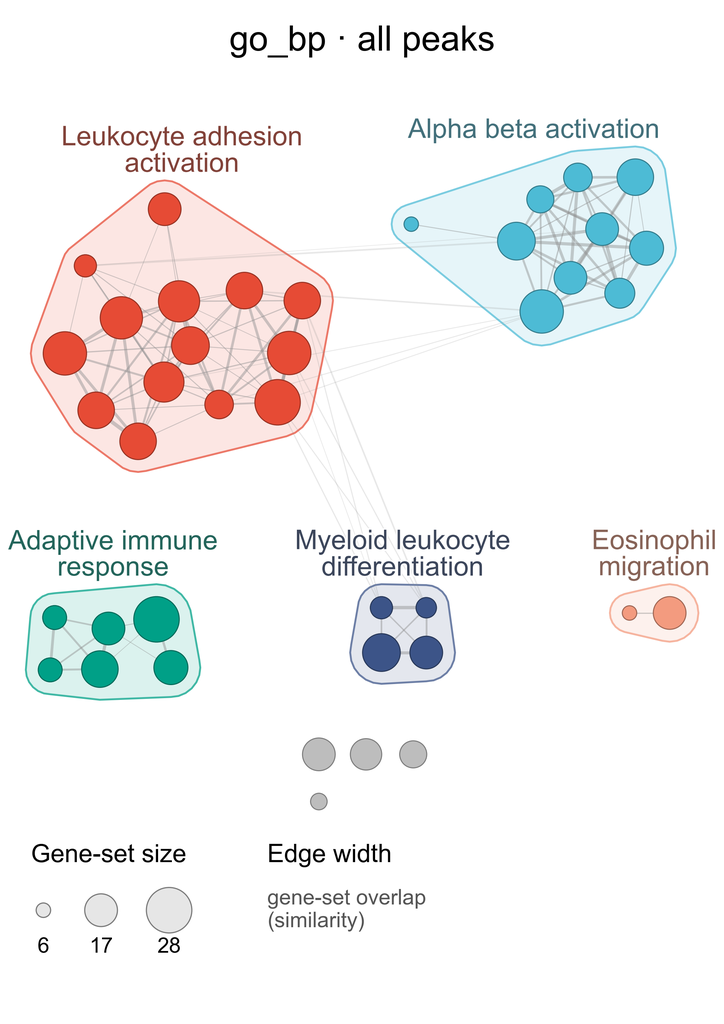

pathway networkDownload: PNG · PDF (vector)

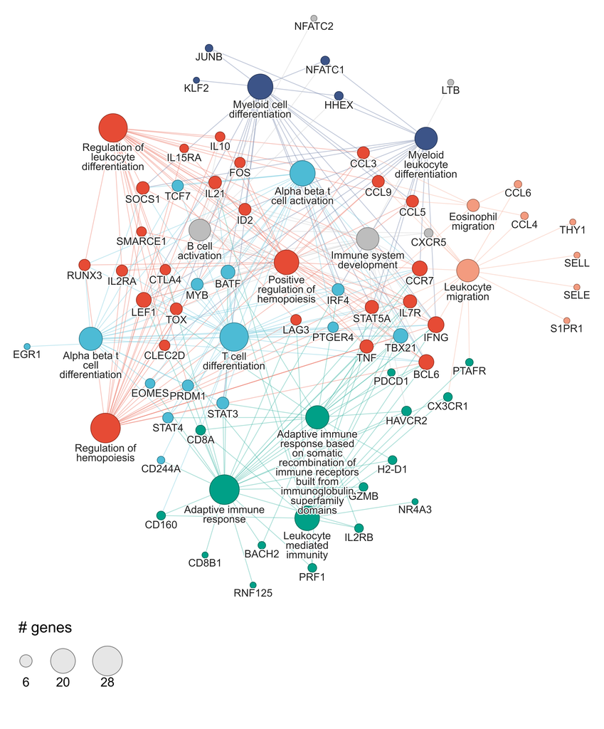

gene networkDownload: PNG · PDF (vector)

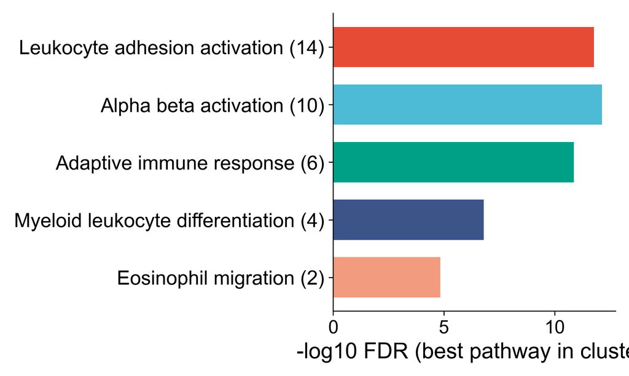

cluster barplotDownload: PNG · PDF (vector)

**Table: clusters - pathway_network_clusters.csv**

| cluster | label | n_nodes | best_fdr | members |
| --- | --- | --- | --- | --- |
| 1 | Leukocyte adhesion activation | 14 | 1.6594983357154457e-12 | GOBP_REGULATION_OF_LEUKOCYTE_DIFFERENTIATION; GOBP_REGULATION_OF_HEMOPOIESIS; GOBP_POSITIVE_REGULATION_OF_HEMOPOIESIS; GOBP_LEUKOCYTE_CELL_CELL_ADHESION; GOBP_REGULATION_OF_LYMPHOCYTE_DIFFERENTIATION;… |
| 2 | Alpha beta activation | 10 | 7.20785430659959e-13 | GOBP_T_CELL_DIFFERENTIATION; GOBP_ALPHA_BETA_T_CELL_ACTIVATION; GOBP_ALPHA_BETA_T_CELL_DIFFERENTIATION; GOBP_CD4_POSITIVE_ALPHA_BETA_T_CELL_ACTIVATION; GOBP_CD4_POSITIVE_ALPHA_BETA_T_CELL_DIFFERENTIAT… |
| 3 | Adaptive immune response | 6 | 1.3425584927768668e-11 | GOBP_ADAPTIVE_IMMUNE_RESPONSE; GOBP_ADAPTIVE_IMMUNE_RESPONSE_BASED_ON_SOMATIC_RECOMBINATION_OF_IMMUNE_RECEPTORS_BUILT_FROM_IMMUNOGLOBULIN_SUPERFAMILY_DOMAINS; GOBP_LEUKOCYTE_MEDIATED_IMMUNITY; GOBP_LY… |
| 4 | Myeloid leukocyte differentiation | 4 | 1.5842722444837576e-07 | GOBP_MYELOID_LEUKOCYTE_DIFFERENTIATION; GOBP_MYELOID_CELL_DIFFERENTIATION; GOBP_POSITIVE_REGULATION_OF_MYELOID_LEUKOCYTE_DIFFERENTIATION; GOBP_POSITIVE_REGULATION_OF_MYELOID_CELL_DIFFERENTIATION |
| 5 | Eosinophil migration | 2 | 1.4406299093578344e-05 | GOBP_EOSINOPHIL_MIGRATION; GOBP_LEUKOCYTE_MIGRATION |

**Table: pathway_nodes - pathway_network_nodes.csv**

| id | name | label | type | fdr | pvalue | nes | direction | set_size | overlap | genes | size_value | cluster | cluster_label | x | y |
| --- | --- | --- | --- | --- | --- | --- | --- | --- | --- | --- | --- | --- | --- | --- | --- |
| GOBP_LEUKOCYTE_CELL_CELL_ADHESION | GOBP_LEUKOCYTE_CELL_CELL_ADHESION | Leukocyte cell cell adhesion | pathway | 1.9634608927612587e-11 | 7.157208600587821e-14 |  |  | 26 | 26 | BCL6;CCL5;CCR7;CD160;CD244A;CTLA4;CX3CR1;HAVCR2;IFNG;IL21;IL2RA;IL7R;LAG3;LEF1;NR4A3;PTAFR;RUNX3;SELE;SELL;SMARCE1;SOCS1;STAT5A;TBX21;THY1;TIGIT;TNF | 26.0 | 1 | Leukocyte adhesion activation | -2.9007554928165558 | -2.410576936856702 |
| GOBP_LEUKOCYTE_PROLIFERATION | GOBP_LEUKOCYTE_PROLIFERATION | Leukocyte proliferation | pathway | 2.8510020855097817e-05 | 4.200469005782394e-07 |  |  | 17 | 17 | BCL6;CCL5;CCR7;CD244A;CTLA4;HAVCR2;HHEX;IFNG;IL10;IL21;IL2RA;IL7R;JUNB;LEF1;NFATC2;STAT4;STAT5A | 17.0 | 1 | Leukocyte adhesion activation | -1.9350637003192623 | -1.0145825984373942 |
| GOBP_POSITIVE_REGULATION_OF_CELL_ACTIVATION | GOBP_POSITIVE_REGULATION_OF_CELL_ACTIVATION | Positive regulation of cell activation | pathway | 1.4892542498132742e-10 | 7.238173753648963e-13 |  |  | 24 | 24 | BCL6;CCL5;CCR7;CD160;CD244A;HAVCR2;IFNG;IL10;IL15RA;IL21;IL2RA;IL7R;LEF1;MYB;NFATC2;NR4A3;RUNX3;SMARCE1;SOCS1;STAT5A;TBX21;THY1;TNF;TOX | 24.0 | 1 | Leukocyte adhesion activation | -1.7960545639981642 | -1.9065530017282233 |
| GOBP_POSITIVE_REGULATION_OF_CELL_CELL_ADHESION | GOBP_POSITIVE_REGULATION_OF_CELL_CELL_ADHESION | Positive regulation of cell cell adhesion | pathway | 1.071455959022563e-08 | 8.245307096568934e-11 |  |  | 20 | 20 | BCL6;CCL5;CCR7;CD160;CD244A;HAVCR2;IFNG;IL21;IL2RA;IL7R;LEF1;NR4A3;PTAFR;RUNX3;SELE;SMARCE1;SOCS1;STAT5A;THY1;TNF | 20.0 | 1 | Leukocyte adhesion activation | -2.192211358359782 | -3.261163505542576 |
| GOBP_POSITIVE_REGULATION_OF_HEMOPOIESIS | GOBP_POSITIVE_REGULATION_OF_HEMOPOIESIS | Positive regulation of hemopoiesis | pathway | 1.1437697383826428e-11 | 3.2427655604206156e-14 |  |  | 20 | 20 | BCL6;CCL3;CCL5;CCL9;CCR7;FOS;ID2;IFNG;IL10;IL15RA;IL21;IL2RA;IL7R;LEF1;RUNX3;SMARCE1;SOCS1;STAT5A;TNF;TOX | 20.0 | 1 | Leukocyte adhesion activation | -0.6031579105419054 | -1.89944123290155 |
| GOBP_POSITIVE_REGULATION_OF_LEUKOCYTE_CELL_CELL_ADHESION | GOBP_POSITIVE_REGULATION_OF_LEUKOCYTE_CELL_CELL_ADHESION | Positive regulation of leukocyte cell cell adhesion | pathway | 5.923883700383138e-10 | 3.3590268045914924e-12 |  |  | 20 | 20 | BCL6;CCL5;CCR7;CD160;CD244A;HAVCR2;IFNG;IL21;IL2RA;IL7R;LEF1;NR4A3;PTAFR;RUNX3;SELE;SMARCE1;SOCS1;STAT5A;THY1;TNF | 20.0 | 1 | Leukocyte adhesion activation | -2.5980351303150244 | -2.961255455916744 |
| GOBP_POSITIVE_REGULATION_OF_LYMPHOCYTE_ACTIVATION | GOBP_POSITIVE_REGULATION_OF_LYMPHOCYTE_ACTIVATION | Positive regulation of lymphocyte activation | pathway | 1.9523707252217623e-09 | 1.2652058162635966e-11 |  |  | 21 | 21 | BCL6;CCL5;CCR7;CD160;CD244A;HAVCR2;IFNG;IL10;IL15RA;IL21;IL2RA;IL7R;LEF1;NFATC2;RUNX3;SMARCE1;SOCS1;STAT5A;TBX21;THY1;TOX | 21.0 | 1 | Leukocyte adhesion activation | -1.6857780164895069 | -2.3346434738494124 |
| GOBP_POSITIVE_REGULATION_OF_LYMPHOCYTE_DIFFERENTIATION | GOBP_POSITIVE_REGULATION_OF_LYMPHOCYTE_DIFFERENTIATION | Positive regulation of lymphocyte differentiation | pathway | 1.3208013611890348e-08 | 1.230394139625265e-10 |  |  | 14 | 14 | BCL6;CCR7;IFNG;IL10;IL15RA;IL21;IL2RA;IL7R;LEF1;RUNX3;SMARCE1;SOCS1;STAT5A;TOX | 14.0 | 1 | Leukocyte adhesion activation | -1.4081146938244409 | -2.904904242147228 |
| GOBP_REGULATION_OF_ALPHA_BETA_T_CELL_ACTIVATION | GOBP_REGULATION_OF_ALPHA_BETA_T_CELL_ACTIVATION | Regulation of alpha beta t cell activation | pathway | 2.8510020855097817e-05 | 4.272461610524986e-07 |  |  | 10 | 10 | BCL6;CCR7;CD160;CD244A;IFNG;IL2RA;PRDM1;RUNX3;SOCS1;TBX21 | 10.0 | 1 | Leukocyte adhesion activation | -2.7024760615960384 | -1.5631729008130577 |
| GOBP_REGULATION_OF_CELL_CELL_ADHESION | GOBP_REGULATION_OF_CELL_CELL_ADHESION | Regulation of cell cell adhesion | pathway | 3.804440302146192e-09 | 2.6195012205947865e-11 |  |  | 25 | 25 | BCL6;CCL5;CCR7;CD160;CD244A;CTLA4;HAVCR2;IFNG;IL10;IL21;IL2RA;IL7R;LAG3;LEF1;NR4A3;PTAFR;RUNX3;SELE;SMARCE1;SOCS1;STAT5A;TBX21;THY1;TIGIT;TNF | 25.0 | 1 | Leukocyte adhesion activation | -2.354144873552601 | -2.0663018579405725 |

Showing 10 of 40 rows.

**Table: pathway_edges - pathway_network_edges.csv**

| source | target | weight | shared |
| --- | --- | --- | --- |
| GOBP_T_CELL_DIFFERENTIATION | GOBP_ALPHA_BETA_T_CELL_ACTIVATION | 0.7917 | 19 |
| GOBP_T_CELL_DIFFERENTIATION | GOBP_ALPHA_BETA_T_CELL_DIFFERENTIATION | 0.8462 | 18 |
| GOBP_T_CELL_DIFFERENTIATION | GOBP_REGULATION_OF_HEMOPOIESIS | 0.6368 | 19 |
| GOBP_T_CELL_DIFFERENTIATION | GOBP_CD4_POSITIVE_ALPHA_BETA_T_CELL_ACTIVATION | 0.7669 | 16 |
| GOBP_T_CELL_DIFFERENTIATION | GOBP_CD4_POSITIVE_ALPHA_BETA_T_CELL_DIFFERENTIATION | 0.7885 | 15 |
| GOBP_T_CELL_DIFFERENTIATION | GOBP_REGULATION_OF_LYMPHOCYTE_DIFFERENTIATION | 0.7181 | 17 |
| GOBP_T_CELL_DIFFERENTIATION | GOBP_T_CELL_DIFFERENTIATION_INVOLVED_IN_IMMUNE_RESPONSE | 0.75 | 13 |
| GOBP_T_CELL_DIFFERENTIATION | GOBP_REGULATION_OF_T_CELL_ACTIVATION | 0.6352 | 17 |
| GOBP_T_CELL_DIFFERENTIATION | GOBP_T_CELL_ACTIVATION_INVOLVED_IN_IMMUNE_RESPONSE | 0.705 | 13 |
| GOBP_T_CELL_DIFFERENTIATION | GOBP_POSITIVE_REGULATION_OF_LYMPHOCYTE_DIFFERENTIATION | 0.6429 | 12 |

Showing 10 of 121 rows.

**Table: gene_nodes - gene_network_nodes.csv**

| id | name | label | type | logfc | n_pathways | pathways | size_value | cluster | cluster_label | x | y | fdr | pvalue | nes | direction | set_size | overlap | genes |
| --- | --- | --- | --- | --- | --- | --- | --- | --- | --- | --- | --- | --- | --- | --- | --- | --- | --- | --- |
| BCL6 | BCL6 | BCL6 | gene |  | 12.0 | Regulation of leukocyte differentiation; T cell differentiation; Adaptive immune response; Immune system development; Regulation of hemopoiesis; Alpha beta t cell activation; Adaptive immune response … | 12.0 | 1 | Leukocyte adhesion activation | 2.0385856483823073 | -1.0344105631676417 |  |  |  |  |  |  |  |
| CCL3 | CCL3 | CCL3 | gene |  | 7.0 | Regulation of leukocyte differentiation; Myeloid leukocyte differentiation; Eosinophil migration; Regulation of hemopoiesis; Myeloid cell differentiation; Leukocyte migration; Positive regulation of h… | 7.0 | 1 | Leukocyte adhesion activation | 1.019417867721659 | 2.353010706524314 |  |  |  |  |  |  |  |
| CCL5 | CCL5 | CCL5 | gene |  | 7.0 | Regulation of leukocyte differentiation; Myeloid leukocyte differentiation; Eosinophil migration; Regulation of hemopoiesis; Myeloid cell differentiation; Leukocyte migration; Positive regulation of h… | 7.0 | 1 | Leukocyte adhesion activation | 1.8134003279545756 | 1.5684504646488362 |  |  |  |  |  |  |  |
| CCL9 | CCL9 | CCL9 | gene |  | 7.0 | Regulation of leukocyte differentiation; Myeloid leukocyte differentiation; Eosinophil migration; Regulation of hemopoiesis; Myeloid cell differentiation; Leukocyte migration; Positive regulation of h… | 7.0 | 1 | Leukocyte adhesion activation | 1.260566970145051 | 1.8902644119713994 |  |  |  |  |  |  |  |
| CCR7 | CCR7 | CCR7 | gene |  | 12.0 | Regulation of leukocyte differentiation; T cell differentiation; Adaptive immune response; Myeloid leukocyte differentiation; Immune system development; Regulation of hemopoiesis; Alpha beta t cell ac… | 12.0 | 1 | Leukocyte adhesion activation | 1.931511481585315 | 0.4811423144225394 |  |  |  |  |  |  |  |
| CLEC2D | CLEC2D | CLEC2D | gene |  | 5.0 | Regulation of leukocyte differentiation; Myeloid leukocyte differentiation; Regulation of hemopoiesis; Myeloid cell differentiation; Leukocyte mediated immunity | 5.0 | 1 | Leukocyte adhesion activation | -2.198051173708318 | -0.7634069386025312 |  |  |  |  |  |  |  |
| CTLA4 | CTLA4 | CTLA4 | gene |  | 5.0 | Regulation of leukocyte differentiation; T cell differentiation; Adaptive immune response; Regulation of hemopoiesis; B cell activation | 5.0 | 1 | Leukocyte adhesion activation | -2.1860500105308853 | 0.46124677856704854 |  |  |  |  |  |  |  |
| FOS | FOS | FOS | gene |  | 5.0 | Regulation of leukocyte differentiation; Myeloid leukocyte differentiation; Regulation of hemopoiesis; Myeloid cell differentiation; Positive regulation of hemopoiesis | 5.0 | 1 | Leukocyte adhesion activation | -0.9787468466347599 | 2.1941045642448707 |  |  |  |  |  |  |  |
| GOBP_POSITIVE_REGULATION_OF_HEMOPOIESIS | GOBP_POSITIVE_REGULATION_OF_HEMOPOIESIS | Positive regulation of hemopoiesis | pathway |  |  |  | 20.0 | 1 | Leukocyte adhesion activation | -0.2252484921979346 | 0.5807965492837849 | 1.1437697383826428e-11 | 3.2427655604206156e-14 |  |  | 20.0 | 20.0 | BCL6;CCL3;CCL5;CCL9;CCR7;FOS;ID2;IFNG;IL10;IL15RA;IL21;IL2RA;IL7R;LEF1;RUNX3;SMARCE1;SOCS1;STAT5A;TNF;TOX |
| GOBP_REGULATION_OF_HEMOPOIESIS | GOBP_REGULATION_OF_HEMOPOIESIS | Regulation of hemopoiesis | pathway |  |  |  | 28.0 | 1 | Leukocyte adhesion activation | -3.155000886352861 | -2.100870860165306 | 2.4316501631176678e-12 | 4.924362420246392e-15 |  |  | 28.0 | 28.0 | BCL6;CCL3;CCL5;CCL9;CCR7;CLEC2D;CTLA4;FOS;ID2;IFNG;IL10;IL15RA;IL21;IL2RA;IL7R;LAG3;LEF1;MYB;PRDM1;RUNX3;SMARCE1;SOCS1;STAT3;STAT5A;TBX21;TCF7;TNF;TOX |

Showing 10 of 77 rows.

E6

### Pathway consensus (PathwayAgent)

skipped

Why: Independent engines on the same gene lists; consensus themes and key genes.

```
PathwayAgent is not installed (clone https://github.com/helenhuangmath/PathwayAgent next to this repository and run its setup, or set PEAKANNOAGENT_PATHWAYAGENT to its `pathwayagent` command).
```

### Motifs and regulators

E3

### ChIP-Atlas submission (TFs and others, All cell types)

ok

Why: Find public TF ChIP-seq that overlaps these peaks.

| request id | wabi_chipatlas_2026-1119-0023-56-938-230279 |
| --- | --- |
| antigen class | TFs and others |
| cell class | All cell types |
| regions | all |

E7

### Known-motif enrichment (all peaks)

skipped

Why: Known-motif enrichment at peak centres.

```
HOMER is not installed; motif enrichment was skipped (install HOMER and its genome package (http://homer.ucsd.edu/homer/) so that findMotifsGenome.pl is on PATH).
```

E8

### Known-motif enrichment (distal peaks)

skipped

Why: Enhancer motifs without promoter GC bias.

```
HOMER is not installed; motif enrichment was skipped (install HOMER and its genome package (http://homer.ucsd.edu/homer/) so that findMotifsGenome.pl is on PATH).
```

E10

### ChIP-Atlas co-binding enrichment

ok

Why: Collect public co-binding results.

| request id | wabi_chipatlas_2026-1119-0023-56-938-230279 |
| --- | --- |
| ready | True |
| n experiments tested | 13850 |
| antigen class | TFs and others |
| cell class | All cell types |
| regions | all |

#### top antigens

| antigen | best_log10_q | best_fold_enrichment | best_experiment | best_cell | n_significant_experiments | n_experiments | cells |
| --- | --- | --- | --- | --- | --- | --- | --- |
| Smc1a | -11.1 | 100 | SRX7348146 | CD4 CD8 double positive cells | 43 | 146 | CD4 CD8 double positive cells, Cerebellum, ES cells, MEF, NIH/3T3, Neutrophils |
| Nipbl | -9.93 | 100 | SRX8694064 | T cells | 65 | 98 | B cells, CD4 CD8 double positive cells, CH12, CH12F3, Neutrophils, P19 |
| Stat3 | -9.7 | 47 | SRX037909 | Th1 Cells | 24 | 81 | CD4+ T cells, Cortical oligodendrocyte progenitor, ES cells, Mammary glands, Th1 Cells, Th17 Cells |
| Ep300 | -9.04 | 24 | SRX183951 | Th1 Cells | 100 | 239 | As4.1, B cells, Brain, Brown preadipocytes, CD4+ T cells, CD8+ T cells |
| Stat5a | -8.78 | 23.5 | SRX037910 | Th1 Cells | 37 | 196 | CD4+ T cells, CD8+ T cells, Leukemia, Mammary glands, Monocytes, Natural killer cells |
| Stat4 | -8.74 | 100 | SRX7726479 | Natural killer cells | 7 | 12 | Natural killer cells, Th1 Cells |
| Eomes | -8.53 | 16.3 | SRX4510927 | OT-1 | 7 | 17 | Natural killer cells, OT-1, Trophoblast stem cells |
| Bcl11b | -8.52 | 10.8 | SRX2399084 | Thymocytes | 25 | 32 | CD4 CD8 double negative cells, CD4+ T cells, CD8+ T cells, Thymocytes, Thymus |
| Kdm1a | -8.52 | 42 | SRX5056006 | Hematopoietic progenitors | 19 | 62 | Bone Marrow Cells, CD4 CD8 double negative cells, ES cells, EpiLC, EpiSC, Granulocytes |
| Satb1 | -8.34 | 41 | SRX13440924 | Thymus | 11 | 23 | CD4+ T cells, Thymocytes, Thymus |
| Usf2 | -8.26 | 22 | SRX3637368 | Macrophages | 4 | 6 | Macrophages |
| Jund | -8.08 | 21.5 | SRX172347 | Th17 Cells | 15 | 31 | CD4+ T cells, CD8+ T cells, CH12, MEF, Macrophages, Th17 Cells |

Showing 12 of 25 rows.

#### top experiments

| experiment | antigen | cell | log10_q | fold_enrichment | overlaps_user |
| --- | --- | --- | --- | --- | --- |
| SRX7348146 | Smc1a | CD4 CD8 double positive cells | -11.1 | 100 | 49/351 |
| SRX7348143 | Smc1a | CD4 CD8 double positive cells | -10.4 | 100 | 46/351 |
| SRX8694064 | Nipbl | T cells | -9.93 | 100 | 44/351 |
| SRX7348144 | Smc1a | CD4 CD8 double positive cells | -9.93 | 48 | 48/351 |
| SRX037909 | Stat3 | Th1 Cells | -9.7 | 47 | 47/351 |
| SRX7348145 | Smc1a | CD4 CD8 double positive cells | -9.22 | 100 | 41/351 |
| SRX183951 | Ep300 | Th1 Cells | -9.04 | 24 | 48/351 |
| SRX037910 | Stat5a | Th1 Cells | -8.78 | 23.5 | 47/351 |
| SRX7726479 | Stat4 | Natural killer cells | -8.74 | 100 | 39/351 |
| SRX4510927 | Eomes | OT-1 | -8.53 | 16.3 | 49/351 |
| SRX7348142 | Smc1a | Thymocytes | -8.52 | 100 | 38/351 |
| SRX4510928 | Eomes | OT-1 | -8.52 | 42 | 42/351 |

Showing 12 of 15 rows.

**Table: chipatlas - tex_chipatlas_230279.tsv**

| experiment | antigen_class | antigen | cell_class | cell | n_peaks | overlaps_user | overlaps_control | log10_p | log10_q | fold_enrichment |
| --- | --- | --- | --- | --- | --- | --- | --- | --- | --- | --- |
| SRX7348146 | TFs and others | Smc1a | Blood | CD4 CD8 double positive cells | 49085 | 49/351 | 0/351 | -15.2317 | -11.0902 | 100.0 |
| SRX7348143 | TFs and others | Smc1a | Blood | CD4 CD8 double positive cells | 49995 | 46/351 | 0/351 | -14.2316 | -10.3912 | 100.0 |
| SRX8694064 | TFs and others | Nipbl | Blood | T cells | 24685 | 44/351 | 0/351 | -13.5687 | -9.93065 | 100.0 |
| SRX7348144 | TFs and others | Smc1a | Blood | CD4 CD8 double positive cells | 52008 | 48/351 | 1/351 | -13.47 | -9.93065 | 48.0 |
| SRX037909 | TFs and others | Stat3 | Blood | Th1 Cells | 54722 | 47/351 | 1/351 | -13.1461 | -9.70363 | 47.0 |
| SRX7348145 | TFs and others | Smc1a | Blood | CD4 CD8 double positive cells | 49235 | 41/351 | 0/351 | -12.5799 | -9.21659 | 100.0 |
| SRX183951 | TFs and others | Ep300 | Blood | Th1 Cells | 41654 | 48/351 | 2/351 | -12.3352 | -9.03885 | 24.0 |
| SRX037910 | TFs and others | Stat5a | Blood | Th1 Cells | 63651 | 47/351 | 2/351 | -12.0205 | -8.78216 | 23.5 |
| SRX7726479 | TFs and others | Stat4 | Blood | Natural killer cells | 34692 | 39/351 | 0/351 | -11.9244 | -8.73723 | 100.0 |
| SRX4510927 | TFs and others | Eomes | Blood | OT-1 | 39141 | 49/351 | 3/351 | -11.6751 | -8.53367 | 16.3333 |

Showing 10 of 13850 rows.

### Integration and controls

E9

### Peak-RNA-seq integration

ok

Why: Link binding to expression changes.

| n tested genes | 47 |
| --- | --- |
| n up | 17 |
| n down | 10 |
| thresholds | padj: 0.05, abs_log2fc: 0.5 |
| up any peak | n_de: 17, n_with_peak: 17, pct_with_peak: 100, background_pct: 59.6, fold: 1.68, pvalue: 7.83e-06 |
| down any peak | n_de: 10, n_with_peak: 10, pct_with_peak: 100, background_pct: 59.6, fold: 1.68, pvalue: 0.00253 |
| up promoter peak | n_de: 17, n_with_peak: 15, pct_with_peak: 88.2, background_pct: 55.3, fold: 1.6, pvalue: 6.34e-04 |
| down promoter peak | n_de: 10, n_with_peak: 10, pct_with_peak: 100, background_pct: 55.3, fold: 1.81, pvalue: 0.00103 |
| top bound de genes | Bach2(down,distal;promoter), Ctla4(up,distal), Klf2(down,distal;promoter), Tigit(up,distal;promoter), Pdcd1(up,distal;promoter), Prdm1(up,distal), Tox(up,distal;promoter), Cd244a(up,promoter), Gzmb(up… |

**Table: rnaseq_integration - tex_rnaseq_integration.tsv**

| gene | direction | log2fc | padj | n_peaks | classes | min_abs_distance |
| --- | --- | --- | --- | --- | --- | --- |
| Bach2 | down | -3.691 | 2.01e-05 | 7 | distal;promoter | 0 |
| Ctla4 | up | 1.904 | 3.1e-05 | 5 | distal | 21935 |
| Klf2 | down | -1.855 | 6.35e-05 | 4 | distal;promoter | 0 |
| Tigit | up | 3.014 | 6.4e-05 | 6 | distal;promoter | 0 |
| Pdcd1 | up | 2.877 | 6.55e-05 | 6 | distal;promoter | 0 |
| Prdm1 | up | 3.637 | 9.75e-05 | 6 | distal | 17061 |
| Tox | up | 2.778 | 0.00013 | 4 | distal;promoter | 0 |
| Cd244a | up | 2.917 | 0.000151 | 2 | promoter | 0 |
| Gzmb | up | 2.485 | 0.000258 | 3 | distal;promoter | 0 |
| Ccr7 | down | -3.096 | 0.000326 | 3 | distal;promoter | 0 |

Showing 10 of 27 rows.

E11

### Positive-control check

ok

Why: Positive controls from the user's known biology.

| genes recovered | 6/6 |
| --- | --- |
| tfs recovered | 1/4 |

#### genes

| gene | bound | n_peaks | classes | min_abs_distance |
| --- | --- | --- | --- | --- |
| Tox | True | 4 | distal, promoter | 0 |
| Pdcd1 | True | 6 | distal, promoter | 0 |
| Havcr2 | True | 2 | promoter | 0 |
| Entpd1 | True | 4 | distal, promoter | 0 |
| Tcf7 | True | 4 | distal, promoter | 0 |
| Cd160 | True | 5 | distal, promoter | 0 |

#### tfs

| tf | chipatlas_rank |
| --- | --- |
| Nfatc1 |  |
| Nr4a1 |  |
| Batf |  |
| Tcf7 | 19 |

### Literature and public data

E12

### Literature: TITLE_ABS:("CD8 T cells") AND TITLE_ABS:(Nfatc1 OR Nr4a1 OR Batf OR Tcf7)

ok

Why: Most-cited papers on these factors in this cell type.

| query | TITLE_ABS:("CD8 T cells") AND TITLE_ABS:(Nfatc1 OR Nr4a1 OR Batf OR Tcf7) |
| --- | --- |

1. [Transcriptional analysis of HIV-specific CD8+ T cells shows that PD-1 inhibits T cell function by upregulating BATF.](https://pubmed.ncbi.nlm.nih.gov/20890291/)  
   Quigley M, Pereyra F, Nilsson B, Porichis F, Fonseca C, Eichbaum Q, Julg B, Jesneck JL, Brosnahan K, Imam S, Russell K,… · *Nature medicine* 2010 · PMID:20890291
2. [Lactate increases stemness of CD8 + T cells to augment anti-tumor immunity.](https://pubmed.ncbi.nlm.nih.gov/36068198/)  
   Feng Q, Liu Z, Yu X, Huang T, Huang T, Chen J, Wang J, Wilhelm J, Li S, Song J, Li W, Sun Z, Sumer BD, Li B, Fu YX, Gao… · *Nature communications* 2022 · PMID:36068198
3. [The transcription factor BATF operates as an essential differentiation checkpoint in early effector CD8+ T cells.](https://pubmed.ncbi.nlm.nih.gov/24584090/)  
   Kurachi M, Barnitz RA, Yosef N, Odorizzi PM, DiIorio MA, Lemieux ME, Yates K, Godec J, Klatt MG, Regev A, Wherry EJ, Ha… · *Nature immunology* 2014 · PMID:24584090
4. [NFATc1 regulates PD-1 expression upon T cell activation.](https://pubmed.ncbi.nlm.nih.gov/18802087/)  
   Oestreich KJ, Yoon H, Ahmed R, Boss JM. · *Journal of immunology (Baltimore, Md. : 1950)* 2008 · PMID:18802087
5. [Functional HPV-specific PD-1+ stem-like CD8 T cells in head and neck cancer.](https://pubmed.ncbi.nlm.nih.gov/34471285/)  
   Eberhardt CS, Kissick HT, Patel MR, Cardenas MA, Prokhnevska N, Obeng RC, Nasti TH, Griffith CC, Im SJ, Wang X, Shin DM… · *Nature* 2021 · PMID:34471285
6. [Dynamic Changes in Chromatin Accessibility Occur in CD8+ T Cells Responding to Viral Infection.](https://pubmed.ncbi.nlm.nih.gov/27939672/)  
   Scott-Browne JP, López-Moyado IF, Trifari S, Wong V, Chavez L, Rao A, Pereira RM. · *Immunity* 2016 · PMID:27939672
7. [PD1Hi CD8+ T cells correlate with exhausted signature and poor clinical outcome in hepatocellular carcinoma.](https://pubmed.ncbi.nlm.nih.gov/31783783/)  
   Ma J, Zheng B, Goswami S, Meng L, Zhang D, Cao C, Li T, Zhu F, Ma L, Zhang Z, Zhang S, Duan M, Chen Q, Gao Q, Zhang X. · *Journal for immunotherapy of cancer* 2019 · PMID:31783783
8. [Abscopal Effects of Radiotherapy Are Enhanced by Combined Immunostimulatory mAbs and Are Dependent on CD8 T Cells and Crosspriming.](https://pubmed.ncbi.nlm.nih.gov/27550452/)  
   Rodriguez-Ruiz ME, Rodriguez I, Garasa S, Barbes B, Solorzano JL, Perez-Gracia JL, Labiano S, Sanmamed MF, Azpilikueta… · *Cancer research* 2016 · PMID:27550452

E13

### GEO datasets: Nfatc1 CD8 T cells ATAC-seq

ok

Why: Comparable public datasets.

| query | Nfatc1 CD8 T cells ATAC-seq |
| --- | --- |

- GSE166718 - Hierarchical interactions between chromatin remodeling transcription factors define the epigenetic landscape of antiviral T cells  
  Expression profiling by high throughput sequencing; Genome binding/occupancy profiling by high throughput sequencing · 84 samples · 2021/12/13 PMID:34937932

## References and datasets

1. [Transcriptional analysis of HIV-specific CD8+ T cells shows that PD-1 inhibits T cell function by upregulating BATF.](https://pubmed.ncbi.nlm.nih.gov/20890291/)  
   Quigley M, Pereyra F, Nilsson B, Porichis F, Fonseca C, Eichbaum Q, Julg B, Jesneck JL, Brosnahan K, Imam S, Russell K,… · *Nature medicine* 2010 · PMID:20890291
2. [Lactate increases stemness of CD8 + T cells to augment anti-tumor immunity.](https://pubmed.ncbi.nlm.nih.gov/36068198/)  
   Feng Q, Liu Z, Yu X, Huang T, Huang T, Chen J, Wang J, Wilhelm J, Li S, Song J, Li W, Sun Z, Sumer BD, Li B, Fu YX, Gao… · *Nature communications* 2022 · PMID:36068198
3. [The transcription factor BATF operates as an essential differentiation checkpoint in early effector CD8+ T cells.](https://pubmed.ncbi.nlm.nih.gov/24584090/)  
   Kurachi M, Barnitz RA, Yosef N, Odorizzi PM, DiIorio MA, Lemieux ME, Yates K, Godec J, Klatt MG, Regev A, Wherry EJ, Ha… · *Nature immunology* 2014 · PMID:24584090
4. [NFATc1 regulates PD-1 expression upon T cell activation.](https://pubmed.ncbi.nlm.nih.gov/18802087/)  
   Oestreich KJ, Yoon H, Ahmed R, Boss JM. · *Journal of immunology (Baltimore, Md. : 1950)* 2008 · PMID:18802087
5. [Functional HPV-specific PD-1+ stem-like CD8 T cells in head and neck cancer.](https://pubmed.ncbi.nlm.nih.gov/34471285/)  
   Eberhardt CS, Kissick HT, Patel MR, Cardenas MA, Prokhnevska N, Obeng RC, Nasti TH, Griffith CC, Im SJ, Wang X, Shin DM… · *Nature* 2021 · PMID:34471285
6. [Dynamic Changes in Chromatin Accessibility Occur in CD8+ T Cells Responding to Viral Infection.](https://pubmed.ncbi.nlm.nih.gov/27939672/)  
   Scott-Browne JP, López-Moyado IF, Trifari S, Wong V, Chavez L, Rao A, Pereira RM. · *Immunity* 2016 · PMID:27939672
7. [PD1Hi CD8+ T cells correlate with exhausted signature and poor clinical outcome in hepatocellular carcinoma.](https://pubmed.ncbi.nlm.nih.gov/31783783/)  
   Ma J, Zheng B, Goswami S, Meng L, Zhang D, Cao C, Li T, Zhu F, Ma L, Zhang Z, Zhang S, Duan M, Chen Q, Gao Q, Zhang X. · *Journal for immunotherapy of cancer* 2019 · PMID:31783783
8. [Abscopal Effects of Radiotherapy Are Enhanced by Combined Immunostimulatory mAbs and Are Dependent on CD8 T Cells and Crosspriming.](https://pubmed.ncbi.nlm.nih.gov/27550452/)  
   Rodriguez-Ruiz ME, Rodriguez I, Garasa S, Barbes B, Solorzano JL, Perez-Gracia JL, Labiano S, Sanmamed MF, Azpilikueta… · *Cancer research* 2016 · PMID:27550452

#### GEO series

- GSE166718 - Hierarchical interactions between chromatin remodeling transcription factors define the epigenetic landscape of antiviral T cells  
  Expression profiling by high throughput sequencing; Genome binding/occupancy profiling by high throughput sequencing · 84 samples · 2021/12/13 PMID:34937932

#### Public experiments (ChIP-Atlas)

- SRX7348146 - Smc1a, CD4 CD8 double positive cells
- SRX7348143 - Smc1a, CD4 CD8 double positive cells
- SRX8694064 - Nipbl, T cells
- SRX7348144 - Smc1a, CD4 CD8 double positive cells
- SRX037909 - Stat3, Th1 Cells
- SRX7348145 - Smc1a, CD4 CD8 double positive cells
- SRX183951 - Ep300, Th1 Cells
- SRX037910 - Stat5a, Th1 Cells
- SRX7726479 - Stat4, Natural killer cells
- SRX4510927 - Eomes, OT-1
- SRX7348142 - Smc1a, Thymocytes
- SRX4510928 - Eomes, OT-1
- SRX5056006 - Kdm1a, Hematopoietic progenitors
- SRX2399084 - Bcl11b, Thymocytes
- SRX1565831 - Ep300, Natural killer cells

## Methods

**Software versions**

| package | version |
| --- | --- |
| SimpNetworkViz | 0.2.0 |
| annotation | gencode.vM25.basic |
| custom | GMT example_tex_signatures.gmt |
| go_bp | MSigDB m5.go.bp.v2024.1.Mm.symbols.gmt |
| hallmark | MSigDB mh.all.v2024.1.Mm.symbols.gmt |
| kegg | Enrichr KEGG_2019_Mouse |

## Analysis log

| step | time | id | tool | status | rationale |
| --- | --- | --- | --- | --- | --- |
| 1 | 10:23:51 | E1 | peak_qc | ok | Baseline QC and cleaning before annotation. |
| 2 | 10:23:52 | E2 | annotate_peaks | ok | Default annotation (-2000/+500 bp promoter window). |
| 3 | 10:23:57 | E3 | chipatlas_submit | ok | Find public TF ChIP-seq that overlaps these peaks. |
| 4 | 10:24:02 | E4 | enrich_pathways | ok | Standard GO/KEGG/Hallmark ORA on peak-linked genes. |
| 5 | 10:24:08 | E5 | network_viz | ok | EnrichmentMap-style view of the GO result: themes instead of redundant terms. |
| 6 | 10:24:08 | E6 | pathway_consensus | skipped | Independent engines on the same gene lists; consensus themes and key genes. |
| 7 | 10:24:08 | E7 | find_motifs | skipped | Known-motif enrichment at peak centres. |
| 8 | 10:24:08 | E8 | find_motifs | skipped | Enhancer motifs without promoter GC bias. |
| 9 | 10:24:08 | E9 | integrate_rnaseq | ok | Link binding to expression changes. |
| 10 | 10:24:13 | E10 | chipatlas_collect | ok | Collect public co-binding results. |
| 11 | 10:24:13 | E11 | check_expectations | ok | Positive controls from the user's known biology. |
| 12 | 10:24:29 | E12 | search_literature | ok | Most-cited papers on these factors in this cell type. |
| 13 | 10:24:29 | E13 | search_geo | ok | Comparable public datasets. |